# Voter Data CVR Washoe

To replicate results:

Load libraries in the console:

```r
library(dplyr)
library(tidyverse)
library(ggplot2)
```

First in the console, import the datafile 2024cvr. Then (also in the console) create a new, identical dataset “cvr”

```r
cvr <- X2024cvr
```

Are there any identical entries in the dataset?

```r
#this chunk counts how many votes have an identical entry
data_check <- cvr %>%
  group_by_all() %>%
  tally(name = "count") %>%
  filter(count > 1)

# Display the number of votes that have an identical entry
print(nrow(data_check))
```

```
[1] 0
```

There are no identical entries in the dataset.

To analyze voting patterns, we remove every column besides the actual voting data and run an analysis to show how many patterns have duplicates.

```r
votingcolumns <- cvr[, 17:ncol(cvr)]
print(head(votingcolumns))
```

| ROSEN, JACKY S. | SCHAEFER, MIKE | WALKER, TROY ZAKARI | NONE OF THESE CANDIDATES...20 | BROWN, SAM | CONRAD, BILL "GREEN BERET" | GRADY, JR., WALTER A. "TONY" | GUNTER, JEFF | HAMILTON, E.T. "EDDYNOMICS" | KENNEDY, RONDA | LINDEMANN, BARRY CAMERON | MABEY, GARN | MARCHANT, JIM | MARINCH, GARY A. | PHILLIPS, STEPHANIE | REGO, VINCENT G. | NONE OF THESE CANDIDATES...33 | AMODEI, MARK E. | SIMON, JR., FRED J. "DOC" | DUERR, NAOMI | KERNS, JOHNNY | TAYLOR, ANGELA D. | ANGLE, SHARRON | GINSBURG, MIKE | NEUMANN, MARK | SAVAGE, SCOTT | SULLIVAN, DIANE "NEVADA MOON" | GOULDING, HEATHER | VELTO, ALEX | BUSHEY, JASON | … |
| --- | --- | --- | --- | --- | --- | --- | --- | --- | --- | --- | --- | --- | --- | --- | --- | --- | --- | --- | --- | --- | --- | --- | --- | --- | --- | --- | --- | --- | --- | --- |
| 1 (85%) | 0 (0%) | 0 (0%) | 0 (0%) | NA | NA | NA | NA | NA | NA | NA | NA | NA | NA | NA | NA | NA | NA | NA | NA | NA | NA | NA | NA | NA | NA | NA | NA | NA | NA | … |
| NA | NA | NA | NA | 1 (64%) | 0 (0%) | 0 (0%) | 0 (0%) | 0 (0%) | 0 (0%) | 0 (0%) | 0 (0%) | 0 (0%) | 0 (0%) | 0 (0%) | 0 (0%) | 0 (0%) | 1 (61%) | 0 (0%) | NA | NA | NA | NA | NA | NA | NA | NA | NA | NA | NA | … |
| 1 (87%) | 0 (0%) | 0 (0%) | 0 (0%) | NA | NA | NA | NA | NA | NA | NA | NA | NA | NA | NA | NA | NA | NA | NA | NA | NA | NA | NA | NA | NA | NA | NA | NA | NA | NA | … |
| NA | NA | NA | NA | 1 (96%) | 0 (0%) | 0 (0%) | 0 (0%) | 0 (0%) | 0 (0%) | 0 (0%) | 0 (0%) | 0 (0%) | 0 (0%) | 0 (0%) | 0 (0%) | 0 (0%) | 1 (94%) | 0 (0%) | NA | NA | NA | NA | NA | NA | NA | NA | NA | NA | NA | … |
| 1 (99%) | 0 (0%) | 0 (0%) | 0 (0%) | NA | NA | NA | NA | NA | NA | NA | NA | NA | NA | NA | NA | NA | NA | NA | NA | NA | NA | NA | NA | NA | NA | NA | NA | NA | NA | … |
| 1 (88%) | 0 (0%) | 0 (0%) | 0 (0%) | NA | NA | NA | NA | NA | NA | NA | NA | NA | NA | NA | NA | NA | NA | NA | NA | NA | NA | NA | NA | NA | NA | NA | NA | NA | NA | … |

| ROSEN, JACKY S. <chr> | SCHAEFER, MIKE <chr> | WALKER, TROY ZAKARI <chr> | NONE OF THESE CANDIDATES...20 <chr> | BROWN, SAM <chr> |  |
| --- | --- | --- | --- | --- | --- |
| 1 (85%) | 0 (0%) | 0 (0%) | 0 (0%) | NA |  |
| NA | NA | NA | NA | 1 (64%) |  |
| 1 (87%) | 0 (0%) | 0 (0%) | 0 (0%) | NA |  |
| NA | NA | NA | NA | 1 (96%) |  |
| 1 (99%) | 0 (0%) | 0 (0%) | 0 (0%) | NA |  |
| 1 (88%) | 0 (0%) | 0 (0%) | 0 (0%) | NA |  |

6 rows | 1-5 of 107 columns

```r
#this chunk counts how many voting patterns have no duplicates
unique_votes <- votingcolumns %>%
  group_by_all() %>%
  tally(name = "count") %>%
  filter(count == 1)

print(nrow(unique_votes))
```

```
[1] 53893
```

```r
#this chunk counts how many voting patterns have at least more than one duplicate
unique_votes_one <- votingcolumns %>%
  group_by_all() %>%
  tally(name = "count") %>%
  filter(count > 1)

# Display the number of unique voting patterns that have one duplicate or more
print(nrow(unique_votes_one))
```

```
[1] 4302
```

```r
# Find voting patterns with at least more than two duplicates
unique_votes_more <- votingcolumns %>%
  group_by_all() %>%
  tally(name = "count") %>%
  filter(count > 2)

# Display the number of unique voting patterns that have more than two duplicates
print(nrow(unique_votes_more))
```

```
[1] 2170
```

There are 53,893 voting patterns across all precincts that do not have a duplicate.

2,132 voting patterns across all precincts have one duplicate.

2,170 voting patterns across all precincts have more than one duplicate.

```
There are several reasons why two people can have identical ballot
patterns:

Random Chance: In elections where candidates are listed in a random
order or where options are chosen randomly (like in some lotteries or
local elections), individuals can have identical ballot patterns purely
by chance.

Limited Choices: In elections with a limited number of candidates or
options, especially in smaller or local elections, the ballot choices
may be more constrained, increasing the likelihood of identical
patterns.

Similar Preferences: Voters with similar political or social views may
independently arrive at the same choices when presented with similar
candidates or issues on the ballot.

Influence of Campaigns or Media: Voter decisions can be influenced by
similar campaign messaging, media coverage, or public opinion, leading
to identical voting patterns among groups of voters.

Voter Guides or Recommendations: Voters may consult the same voter
guides, endorsements, or recommendations from trusted sources, resulting
in similar ballot selections.

Strategic Voting: In some cases, voters may strategically choose
candidates based on perceived electability or other strategic
considerations, leading to similar ballot patterns.

These factors can contribute to the occurrence of identical ballot
patterns among different voters, even in diverse electoral contexts.
```

Now let’s see how those numbers change when we add precinct data.

Run this in the console:

```r
#this removes every column except the counting group, precinct portion, and the vote patterns
subset_cvr <- cvr[, c("CountingGroup", "PrecinctPortion", names(cvr)[17:ncol(cvr)])]

#This dataset looks like this:
print(head(subset_cvr, 10))
```

| CountingGroup | PrecinctPortion | ROSEN, JACKY S. | SCHAEFER, MIKE | WALKER, TROY ZAKARI | NONE OF THESE CANDIDATES...20 | BROWN, SAM | CONRAD, BILL "GREEN BERET" | GRADY, JR., WALTER A. "TONY" | GUNTER, JEFF | HAMILTON, E.T. "EDDYNOMICS" | KENNEDY, RONDA | LINDEMANN, BARRY CAMERON | MABEY, GARN | MARCHANT, JIM | MARINCH, GARY A. | PHILLIPS, STEPHANIE | REGO, VINCENT G. | NONE OF THESE CANDIDATES...33 | AMODEI, MARK E. | SIMON, JR., FRED J. "DOC" | DUERR, NAOMI | KERNS, JOHNNY | TAYLOR, ANGELA D. | ANGLE, SHARRON | GINSBURG, MIKE | NEUMANN, MARK | SAVAGE, SCOTT | SULLIVAN, DIANE "NEVADA MOON" | GOULDING, HEATHER | … |
| --- | --- | --- | --- | --- | --- | --- | --- | --- | --- | --- | --- | --- | --- | --- | --- | --- | --- | --- | --- | --- | --- | --- | --- | --- | --- | --- | --- | --- | --- | --- |
| Mail | RENO-VERDI 2010 (2010) | 1 (85%) | 0 (0%) | 0 (0%) | 0 (0%) | NA | NA | NA | NA | NA | NA | NA | NA | NA | NA | NA | NA | NA | NA | NA | NA | NA | NA | NA | NA | NA | NA | NA | NA | … |
| Mail | RENO-VERDI 2010 (2010) | NA | NA | NA | NA | 1 (64%) | 0 (0%) | 0 (0%) | 0 (0%) | 0 (0%) | 0 (0%) | 0 (0%) | 0 (0%) | 0 (0%) | 0 (0%) | 0 (0%) | 0 (0%) | 0 (0%) | 1 (61%) | 0 (0%) | NA | NA | NA | NA | NA | NA | NA | NA | NA | … |
| Mail | RENO-VERDI 2010 (2010) | 1 (87%) | 0 (0%) | 0 (0%) | 0 (0%) | NA | NA | NA | NA | NA | NA | NA | NA | NA | NA | NA | NA | NA | NA | NA | NA | NA | NA | NA | NA | NA | NA | NA | NA | … |
| Mail | RENO-VERDI 2010 (2010) | NA | NA | NA | NA | 1 (96%) | 0 (0%) | 0 (0%) | 0 (0%) | 0 (0%) | 0 (0%) | 0 (0%) | 0 (0%) | 0 (0%) | 0 (0%) | 0 (0%) | 0 (0%) | 0 (0%) | 1 (94%) | 0 (0%) | NA | NA | NA | NA | NA | NA | NA | NA | NA | … |
| Mail | RENO-VERDI 2010 (2010) | 1 (99%) | 0 (0%) | 0 (0%) | 0 (0%) | NA | NA | NA | NA | NA | NA | NA | NA | NA | NA | NA | NA | NA | NA | NA | NA | NA | NA | NA | NA | NA | NA | NA | NA | … |
| Mail | RENO-VERDI 2010 (2010) | 1 (88%) | 0 (0%) | 0 (0%) | 0 (0%) | NA | NA | NA | NA | NA | NA | NA | NA | NA | NA | NA | NA | NA | NA | NA | NA | NA | NA | NA | NA | NA | NA | NA | NA | … |
| Mail | RENO-VERDI 2010 (2010) | NA | NA | NA | NA | NA | NA | NA | NA | NA | NA | NA | NA | NA | NA | NA | NA | NA | NA | NA | NA | NA | NA | NA | NA | NA | NA | NA | NA | … |
| Mail | RENO-VERDI 2010 (2010) | 1 (100%) | 0 (0%) | 0 (0%) | 0 (0%) | NA | NA | NA | NA | NA | NA | NA | NA | NA | NA | NA | NA | NA | NA | NA | NA | NA | NA | NA | NA | NA | NA | NA | NA | … |
| Mail | RENO-VERDI 2010 (2010) | 1 (88%) | 0 (0%) | 0 (0%) | 0 (0%) | NA | NA | NA | NA | NA | NA | NA | NA | NA | NA | NA | NA | NA | NA | NA | NA | NA | NA | NA | NA | NA | NA | NA | NA | … |
| Mail | RENO-VERDI 2010 (2010) | NA | NA | NA | NA | 0 (0%) | 0 (0%) | 0 (0%) | 0 (0%) | 0 (0%) | 1 (99%) | 0 (0%) | 0 (0%) | 0 (0%) | 0 (0%) | 0 (0%) | 0 (0%) | 0 (0%) | 1 (95%) | 0 (0%) | NA | NA | NA | NA | NA | NA | NA | NA | NA | … |

| CountingGroup <chr> | PrecinctPortion <chr> | ROSEN, JACKY S. <chr> | SCHAEFER, MIKE <chr> | WALKER, TROY ZAKARI <chr> |  |
| --- | --- | --- | --- | --- | --- |
| Mail | RENO-VERDI 2010 (2010) | 1 (85%) | 0 (0%) | 0 (0%) |  |
| Mail | RENO-VERDI 2010 (2010) | NA | NA | NA |  |
| Mail | RENO-VERDI 2010 (2010) | 1 (87%) | 0 (0%) | 0 (0%) |  |
| Mail | RENO-VERDI 2010 (2010) | NA | NA | NA |  |
| Mail | RENO-VERDI 2010 (2010) | 1 (99%) | 0 (0%) | 0 (0%) |  |
| Mail | RENO-VERDI 2010 (2010) | 1 (88%) | 0 (0%) | 0 (0%) |  |
| Mail | RENO-VERDI 2010 (2010) | NA | NA | NA |  |
| Mail | RENO-VERDI 2010 (2010) | 1 (100%) | 0 (0%) | 0 (0%) |  |
| Mail | RENO-VERDI 2010 (2010) | 1 (88%) | 0 (0%) | 0 (0%) |  |
| Mail | RENO-VERDI 2010 (2010) | NA | NA | NA |  |

1-10 of 10 rows | 1-5 of 109 columns

```r
# Adjust column indices as per your dataset
# Find unique voting patterns and count duplicates

#this chunk counts how many votes do not have duplicates
unique_votes_subset <- subset_cvr %>%
  group_by_all() %>%
  tally(name = "count") %>%
  filter(count == 1)

# Display the number of unique voting patterns that do not have duplicates
print(nrow(unique_votes_subset))
```

```
[1] 65647
```

```r
#this chunk counts how many votes have at least more than one duplicate
unique_votes_subset_one <- subset_cvr %>%
  group_by_all() %>%
  tally(name = "count") %>%
  filter(count > 1)

# Display the number of unique voting patterns that have one duplicate or more
print(nrow(unique_votes_subset_one))
```

```
[1] 4887
```

```r
# Find voting patterns with at least more than two duplicates
unique_votes_subset_more <- subset_cvr %>%
  group_by_all() %>%
  tally(name = "count") %>%
  filter(count > 2)

# Display the number of unique voting patterns that have more than two duplicates
print(nrow(unique_votes_subset_more))
```

```
[1] 1738
```

When precinct data is taken into account: There are 65,647 voting patterns that do not have a duplicate.

3,149 voting patterns have one duplicate.

1,738 voting patterns have more than one duplicate. ~~~~~~~~~~~~~~~~~~~~~~~~~~~~~~~~~~~~~~~~~~~~~~~~~~~~~~~~~~~~~~~~~~~~~~~~~~~~~~~

How are those numbers broken down by counting group and precinct?

```r
grouped_data <- unique_votes_subset_one %>%
  group_by(CountingGroup, PrecinctPortion) %>%
  tally(name = "count") %>%
  filter(count > 1)

# Split the data by CountingGroup
split_data <- split(grouped_data, grouped_data$CountingGroup)

# Print tables for each CountingGroup sorted by count in descending order
for (group in names(split_data)) {
  cat("\nCounting Group:", group, "\n")
  sorted_table <- split_data[[group]] %>%
    arrange(desc(count))  # Sort by count column in descending order
  print(head(sorted_table))
  cat("\n")
}
```

```
Counting Group: Early Voting
```

| CountingGroup | PrecinctPortion | count |
| --- | --- | --- |
| Early Voting | SPARKS 7417 (7417) | 35 |
| Early Voting | RENO-VERDI 1026 (1026) | 31 |
| Early Voting | RENO-VERDI 1007 (1007) | 28 |
| Early Voting | RENO-VERDI 5030 (5030) | 26 |
| Early Voting | RENO-VERDI 8205 (8205) | 26 |
| Early Voting | RENO-VERDI 8401 (8401) | 26 |

| CountingGroup <chr> | PrecinctPortion <chr> | count <int> |  |  |
| --- | --- | --- | --- | --- |
| Early Voting | SPARKS 7417 (7417) | 35 |  |  |
| Early Voting | RENO-VERDI 1026 (1026) | 31 |  |  |
| Early Voting | RENO-VERDI 1007 (1007) | 28 |  |  |
| Early Voting | RENO-VERDI 5030 (5030) | 26 |  |  |
| Early Voting | RENO-VERDI 8205 (8205) | 26 |  |  |
| Early Voting | RENO-VERDI 8401 (8401) | 26 |  |  |

6 rows

```
Counting Group: Election Day
```

| CountingGroup | PrecinctPortion | count |
| --- | --- | --- |
| Election Day | RENO-VERDI 8401 (8401) | 29 |
| Election Day | SPARKS 7417 (7417) | 29 |
| Election Day | RENO-VERDI 1008 (1008) | 27 |
| Election Day | RENO-VERDI 7520 (7520) | 27 |
| Election Day | SPARKS 7407 (7407) | 27 |
| Election Day | SPARKS 7415 (7415) | 27 |

| CountingGroup <chr> | PrecinctPortion <chr> | count <int> |  |  |
| --- | --- | --- | --- | --- |
| Election Day | RENO-VERDI 8401 (8401) | 29 |  |  |
| Election Day | SPARKS 7417 (7417) | 29 |  |  |
| Election Day | RENO-VERDI 1008 (1008) | 27 |  |  |
| Election Day | RENO-VERDI 7520 (7520) | 27 |  |  |
| Election Day | SPARKS 7407 (7407) | 27 |  |  |
| Election Day | SPARKS 7415 (7415) | 27 |  |  |

6 rows

```
Counting Group: Mail
```

| CountingGroup | PrecinctPortion | count |
| --- | --- | --- |
| Mail | SPARKS 6308 (6308) | 67 |
| Mail | SPARKS 6320 (6320) | 58 |
| Mail | SPARKS 7417 (7417) | 51 |
| Mail | SPARKS 6300 (6300) | 45 |
| Mail | SPARKS 6403 (6403) | 42 |
| Mail | SPARKS 6413 (6413) | 40 |

| CountingGroup <chr> | PrecinctPortion <chr> | count <int> |  |  |
| --- | --- | --- | --- | --- |
| Mail | SPARKS 6308 (6308) | 67 |  |  |
| Mail | SPARKS 6320 (6320) | 58 |  |  |
| Mail | SPARKS 7417 (7417) | 51 |  |  |
| Mail | SPARKS 6300 (6300) | 45 |  |  |
| Mail | SPARKS 6403 (6403) | 42 |  |  |
| Mail | SPARKS 6413 (6413) | 40 |  |  |

6 rows

```r
#to get the full list, print(sorted_table)
```

```r
grouped_data_more <- unique_votes_subset_more %>%
  group_by(CountingGroup, PrecinctPortion) %>%
  tally(name = "count") %>%
  filter(count > 2)

# Split the data by CountingGroup
split_data_more <- split(grouped_data_more, grouped_data_more$CountingGroup)

# Print tables for each CountingGroup sorted by count in descending order
for (group in names(split_data_more)) {
  cat("\nCounting Group:", group, "\n")
  sorted_table <- split_data_more[[group]] %>%
    arrange(desc(count))  # Sort by count column in descending order
  print(head(sorted_table))
  cat("\n")
}
```

```
Counting Group: Early Voting
```

| CountingGroup | PrecinctPortion | count |
| --- | --- | --- |
| Early Voting | SPARKS 7417 (7417) | 24 |
| Early Voting | SPARKS 7416 (7416) | 18 |
| Early Voting | SPARKS 7410 (7410) | 17 |
| Early Voting | RENO-VERDI 1026 (1026) | 16 |
| Early Voting | SPARKS 6423 (6423) | 16 |
| Early Voting | SPARKS 7407 (7407) | 16 |

| CountingGroup <chr> | PrecinctPortion <chr> | count <int> |  |  |
| --- | --- | --- | --- | --- |
| Early Voting | SPARKS 7417 (7417) | 24 |  |  |
| Early Voting | SPARKS 7416 (7416) | 18 |  |  |
| Early Voting | SPARKS 7410 (7410) | 17 |  |  |
| Early Voting | RENO-VERDI 1026 (1026) | 16 |  |  |
| Early Voting | SPARKS 6423 (6423) | 16 |  |  |
| Early Voting | SPARKS 7407 (7407) | 16 |  |  |

6 rows

```
Counting Group: Election Day
```

| CountingGroup | PrecinctPortion | count |
| --- | --- | --- |
| Election Day | SPARKS 7417 (7417) | 24 |
| Election Day | SPARKS 6413 (6413) | 19 |
| Election Day | SPARKS 7407 (7407) | 18 |
| Election Day | SPARKS 6308 (6308) | 17 |
| Election Day | SPARKS 6320 (6320) | 15 |
| Election Day | SPARKS 7415 (7415) | 15 |

| CountingGroup <chr> | PrecinctPortion <chr> | count <int> |  |  |
| --- | --- | --- | --- | --- |
| Election Day | SPARKS 7417 (7417) | 24 |  |  |
| Election Day | SPARKS 6413 (6413) | 19 |  |  |
| Election Day | SPARKS 7407 (7407) | 18 |  |  |
| Election Day | SPARKS 6308 (6308) | 17 |  |  |
| Election Day | SPARKS 6320 (6320) | 15 |  |  |
| Election Day | SPARKS 7415 (7415) | 15 |  |  |

6 rows

```
Counting Group: Mail
```

| CountingGroup | PrecinctPortion | count |
| --- | --- | --- |
| Mail | SPARKS 6308 (6308) | 27 |
| Mail | SPARKS 6320 (6320) | 23 |
| Mail | SPARKS 6300 (6300) | 17 |
| Mail | SPARKS 7417 (7417) | 15 |
| Mail | SPARKS 6413 (6413) | 14 |
| Mail | SPARKS 6403 (6403) | 13 |

| CountingGroup <chr> | PrecinctPortion <chr> | count <int> |  |  |
| --- | --- | --- | --- | --- |
| Mail | SPARKS 6308 (6308) | 27 |  |  |
| Mail | SPARKS 6320 (6320) | 23 |  |  |
| Mail | SPARKS 6300 (6300) | 17 |  |  |
| Mail | SPARKS 7417 (7417) | 15 |  |  |
| Mail | SPARKS 6413 (6413) | 14 |  |  |
| Mail | SPARKS 6403 (6403) | 13 |  |  |

6 rows

```r
#to get the full list, print(sorted_table)
```

How does that compare to all votes?

```r
all_groups <- cvr %>%
  group_by(CountingGroup, PrecinctPortion) %>%
  tally(name = "count")

# Split the data by CountingGroup
split_data_group <- split(all_groups, all_groups$CountingGroup)

# Print tables for each CountingGroup sorted by count in descending order
for (group in names(split_data_group)) {
  cat("\nCounting Group:", group, "\n")
  sorted_table <- split_data_group[[group]] %>%
    arrange(desc(count))  # Sort by count column in descending order
  print(sorted_table)
  cat("\n")
}
```

```
Counting Group: Early Voting
```

| CountingGroup | PrecinctPortion | count |
| --- | --- | --- |
| Early Voting | RENO-VERDI 1026 (1026) | 213 |
| Early Voting | SPARKS 7417 (7417) | 203 |
| Early Voting | RENO-VERDI 2027 (2027) | 171 |
| Early Voting | RENO-VERDI 1008 (1008) | 165 |
| Early Voting | RENO-VERDI 1007 (1007) | 161 |
| Early Voting | SPARKS 7415 (7415) | 161 |
| Early Voting | RENO-VERDI 8401 (8401) | 157 |
| Early Voting | SPARKS 7410 (7410) | 142 |
| Early Voting | SPARKS 7416 (7416) | 137 |
| Early Voting | RENO-VERDI 2013 (2013) | 135 |

[output cut: 241 more lines]

| CountingGroup <chr> | PrecinctPortion <chr> | count <int> |  |  |
| --- | --- | --- | --- | --- |
| Early Voting | RENO-VERDI 1026 (1026) | 213 |  |  |
| Early Voting | SPARKS 7417 (7417) | 203 |  |  |
| Early Voting | RENO-VERDI 2027 (2027) | 171 |  |  |
| Early Voting | RENO-VERDI 1008 (1008) | 165 |  |  |
| Early Voting | RENO-VERDI 1007 (1007) | 161 |  |  |
| Early Voting | SPARKS 7415 (7415) | 161 |  |  |
| Early Voting | RENO-VERDI 8401 (8401) | 157 |  |  |
| Early Voting | SPARKS 7410 (7410) | 142 |  |  |
| Early Voting | SPARKS 7416 (7416) | 137 |  |  |
| Early Voting | RENO-VERDI 2013 (2013) | 135 |  |  |

Next

...

26

Previous

1-10 of 251 rows

```
Counting Group: Election Day
```

| CountingGroup | PrecinctPortion | count |
| --- | --- | --- |
| Election Day | SPARKS 7407 (7407) | 204 |
| Election Day | RENO-VERDI 1026 (1026) | 194 |
| Election Day | SPARKS 7417 (7417) | 177 |
| Election Day | RENO-VERDI 5045 (5045) | 174 |
| Election Day | RENO-VERDI 1008 (1008) | 168 |
| Election Day | RENO-VERDI 2027 (2027) | 160 |
| Election Day | SPARKS 6308 (6308) | 155 |
| Election Day | SPARKS 7410 (7410) | 155 |
| Election Day | RENO-VERDI 1007 (1007) | 150 |
| Election Day | RENO-VERDI 8401 (8401) | 146 |

[output cut: 233 more lines]

| CountingGroup <chr> | PrecinctPortion <chr> | count <int> |  |  |
| --- | --- | --- | --- | --- |
| Election Day | SPARKS 7407 (7407) | 204 |  |  |
| Election Day | RENO-VERDI 1026 (1026) | 194 |  |  |
| Election Day | SPARKS 7417 (7417) | 177 |  |  |
| Election Day | RENO-VERDI 5045 (5045) | 174 |  |  |
| Election Day | RENO-VERDI 1008 (1008) | 168 |  |  |
| Election Day | RENO-VERDI 2027 (2027) | 160 |  |  |
| Election Day | SPARKS 6308 (6308) | 155 |  |  |
| Election Day | SPARKS 7410 (7410) | 155 |  |  |
| Election Day | RENO-VERDI 1007 (1007) | 150 |  |  |
| Election Day | RENO-VERDI 8401 (8401) | 146 |  |  |

Next

...

25

Previous

1-10 of 243 rows

```
Counting Group: Mail
```

| CountingGroup | PrecinctPortion | count |
| --- | --- | --- |
| Mail | RENO-VERDI 5045 (5045) | 1301 |
| Mail | RENO-VERDI 1007 (1007) | 908 |
| Mail | RENO-VERDI 1026 (1026) | 803 |
| Mail | RENO-VERDI 2041 (2041) | 796 |
| Mail | RENO-VERDI 5030 (5030) | 760 |
| Mail | RENO-VERDI 2027 (2027) | 724 |
| Mail | SPARKS 6308 (6308) | 691 |
| Mail | RENO-VERDI 8401 (8401) | 668 |
| Mail | RENO-VERDI 5031 (5031) | 661 |
| Mail | RENO-VERDI 2035 (2035) | 640 |

[output cut: 264 more lines]

| CountingGroup <chr> | PrecinctPortion <chr> | count <int> |  |  |
| --- | --- | --- | --- | --- |
| Mail | RENO-VERDI 5045 (5045) | 1301 |  |  |
| Mail | RENO-VERDI 1007 (1007) | 908 |  |  |
| Mail | RENO-VERDI 1026 (1026) | 803 |  |  |
| Mail | RENO-VERDI 2041 (2041) | 796 |  |  |
| Mail | RENO-VERDI 5030 (5030) | 760 |  |  |
| Mail | RENO-VERDI 2027 (2027) | 724 |  |  |
| Mail | SPARKS 6308 (6308) | 691 |  |  |
| Mail | RENO-VERDI 8401 (8401) | 668 |  |  |
| Mail | RENO-VERDI 5031 (5031) | 661 |  |  |
| Mail | RENO-VERDI 2035 (2035) | 640 |  |  |

Next

...

28

Previous

1-10 of 274 rows

```
NA
```

Let’s see how that information looks together:

```r
# Identify top counts in the smaller set
top_counts_duplicates <- grouped_data %>%
  arrange(desc(count)) %>%
  slice_head(n = 10)  # Example: Selecting top 10 counts, adjust as needed

# Match top counts with larger set
comparison_table <- top_counts_duplicates %>%
  left_join(all_groups, by = c("CountingGroup", "PrecinctPortion"), suffix = c("_duplicates", "_all"))

# Print the comparison table
#print(comparison_table)

# Split the data by CountingGroup
split_data_table <- split(comparison_table, comparison_table$CountingGroup)

# Print tables for each CountingGroup sorted by count in descending order
for (group in names(split_data_table)) {
  cat("\nCounting Group:", group, "\n")
  sorted_table <- split_data_table[[group]] %>%
    arrange(desc(count_duplicates))  # Sort by count column in descending order
  print(sorted_table)
  cat("\n")
}
```

```
Counting Group: Early Voting
```

| CountingGroup | PrecinctPortion | count_duplicates | count_all |
| --- | --- | --- | --- |
| Early Voting | SPARKS 7417 (7417) | 35 | 203 |
| Early Voting | RENO-VERDI 1026 (1026) | 31 | 213 |
| Early Voting | RENO-VERDI 1007 (1007) | 28 | 161 |
| Early Voting | RENO-VERDI 5030 (5030) | 26 | 123 |
| Early Voting | RENO-VERDI 8205 (8205) | 26 | 128 |
| Early Voting | RENO-VERDI 8401 (8401) | 26 | 157 |
| Early Voting | SPARKS 7410 (7410) | 25 | 142 |
| Early Voting | SPARKS 7416 (7416) | 24 | 137 |
| Early Voting | RENO-VERDI 3005 (3005) | 23 | 109 |
| Early Voting | SPARKS 6413 (6413) | 23 | 129 |

| CountingGroup <chr> | PrecinctPortion <chr> | count_duplicates <int> | count_all <int> |  |
| --- | --- | --- | --- | --- |
| Early Voting | SPARKS 7417 (7417) | 35 | 203 |  |
| Early Voting | RENO-VERDI 1026 (1026) | 31 | 213 |  |
| Early Voting | RENO-VERDI 1007 (1007) | 28 | 161 |  |
| Early Voting | RENO-VERDI 5030 (5030) | 26 | 123 |  |
| Early Voting | RENO-VERDI 8205 (8205) | 26 | 128 |  |
| Early Voting | RENO-VERDI 8401 (8401) | 26 | 157 |  |
| Early Voting | SPARKS 7410 (7410) | 25 | 142 |  |
| Early Voting | SPARKS 7416 (7416) | 24 | 137 |  |
| Early Voting | RENO-VERDI 3005 (3005) | 23 | 109 |  |
| Early Voting | SPARKS 6413 (6413) | 23 | 129 |  |

1-10 of 10 rows

```
Counting Group: Election Day
```

| CountingGroup | PrecinctPortion | count_duplicates | count_all |
| --- | --- | --- | --- |
| Election Day | RENO-VERDI 8401 (8401) | 29 | 146 |
| Election Day | SPARKS 7417 (7417) | 29 | 177 |
| Election Day | RENO-VERDI 1008 (1008) | 27 | 168 |
| Election Day | RENO-VERDI 7520 (7520) | 27 | 116 |
| Election Day | SPARKS 7407 (7407) | 27 | 204 |
| Election Day | SPARKS 7415 (7415) | 27 | 146 |
| Election Day | RENO-VERDI 5045 (5045) | 25 | 174 |
| Election Day | SPARKS 7410 (7410) | 24 | 155 |
| Election Day | SPARKS 7502 (7502) | 24 | 98 |
| Election Day | RENO-VERDI 2033 (2033) | 23 | 128 |

| CountingGroup <chr> | PrecinctPortion <chr> | count_duplicates <int> | count_all <int> |  |
| --- | --- | --- | --- | --- |
| Election Day | RENO-VERDI 8401 (8401) | 29 | 146 |  |
| Election Day | SPARKS 7417 (7417) | 29 | 177 |  |
| Election Day | RENO-VERDI 1008 (1008) | 27 | 168 |  |
| Election Day | RENO-VERDI 7520 (7520) | 27 | 116 |  |
| Election Day | SPARKS 7407 (7407) | 27 | 204 |  |
| Election Day | SPARKS 7415 (7415) | 27 | 146 |  |
| Election Day | RENO-VERDI 5045 (5045) | 25 | 174 |  |
| Election Day | SPARKS 7410 (7410) | 24 | 155 |  |
| Election Day | SPARKS 7502 (7502) | 24 | 98 |  |
| Election Day | RENO-VERDI 2033 (2033) | 23 | 128 |  |

1-10 of 10 rows

```
Counting Group: Mail
```

| CountingGroup | PrecinctPortion | count_duplicates | count_all |
| --- | --- | --- | --- |
| Mail | SPARKS 6308 (6308) | 67 | 691 |
| Mail | SPARKS 6320 (6320) | 58 | 612 |
| Mail | SPARKS 7417 (7417) | 51 | 628 |
| Mail | SPARKS 6300 (6300) | 45 | 395 |
| Mail | SPARKS 6403 (6403) | 42 | 504 |
| Mail | SPARKS 6413 (6413) | 40 | 507 |
| Mail | SPARKS 6423 (6423) | 39 | 565 |
| Mail | SPARKS 7410 (7410) | 39 | 440 |
| Mail | SPARKS 7407 (7407) | 37 | 539 |
| Mail | SPARKS 6500 (6500) | 35 | 382 |

| CountingGroup <chr> | PrecinctPortion <chr> | count_duplicates <int> | count_all <int> |  |
| --- | --- | --- | --- | --- |
| Mail | SPARKS 6308 (6308) | 67 | 691 |  |
| Mail | SPARKS 6320 (6320) | 58 | 612 |  |
| Mail | SPARKS 7417 (7417) | 51 | 628 |  |
| Mail | SPARKS 6300 (6300) | 45 | 395 |  |
| Mail | SPARKS 6403 (6403) | 42 | 504 |  |
| Mail | SPARKS 6413 (6413) | 40 | 507 |  |
| Mail | SPARKS 6423 (6423) | 39 | 565 |  |
| Mail | SPARKS 7410 (7410) | 39 | 440 |  |
| Mail | SPARKS 7407 (7407) | 37 | 539 |  |
| Mail | SPARKS 6500 (6500) | 35 | 382 |  |

1-10 of 10 rows

```
NA
```

The greatest number of duplicate voting patterns are in Sparks 6308 with 67/691 voting patterns.

Having 67 out of 691 voters in one precinct with the same voting pattern can depend on specific factors related to the election, the precinct, and the voting patterns themselves:

Type of Election: The type of election (local, state, national) and the nature of the candidates or issues involved can influence voting patterns. In elections with fewer candidates or more polarizing issues, it might be more common to see clusters of voters with similar patterns.

Demographics: The demographics of the precinct, including factors such as age, socioeconomic status, education level, and cultural background, can influence voting behavior. Similar demographic profiles among voters might lead to more uniform voting patterns.

Campaign Dynamics: Effective campaigning or issues that resonate strongly with voters in that precinct could lead to a higher degree of similarity in voting patterns.

Historical Context: Comparing the current election’s voting patterns with past elections in the same precinct or similar elections elsewhere can provide context for understanding whether the observed patterns are typical or unusual.

Random Chance: While less likely with larger sample sizes, random chance can still play a role, particularly if there are fewer options on the ballot or if voters make decisions independently but coincidentally arrive at the same choices.

Keep Sparks 6308 in mind when looking at the next section of data.

In a graph, it looks like this:

Keep in mind that the count labels for Mail on the y axis is different from the Early Voting and Election Day counts!

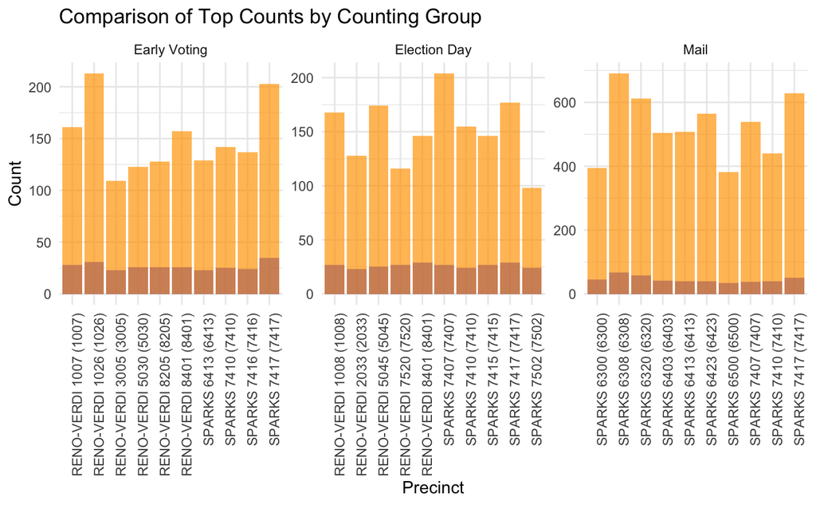

```r
library(ggplot2)

# Create separate plots faceted by CountingGroup
ggplot(comparison_table, aes(x = PrecinctPortion)) +
  geom_bar(aes(y = count_duplicates), stat = "identity", fill = "blue", alpha = 0.7) +
  geom_bar(aes(y = count_all), stat = "identity", fill = "orange", alpha = 0.7) +
  facet_wrap(~ CountingGroup, scales = "free") +
  labs(title = "Comparison of Top Counts by Counting Group",
       x = "Precinct",
       y = "Count") +
  theme_minimal() +
  theme(axis.text.x = element_text(angle = 90, hjust = 1))  # Rotate labels by 45 degrees
```

If we separate the votes that have one duplicate from more than one duplicate, it looks like this:

```r
#create a new table adding a column for grouped_data_more
grouped_data_more2 <- grouped_data_more %>%
  rename("count_moreduplicates" = "count")

comparison_table_all <- comparison_table %>%
  left_join(grouped_data_more2, by = c("CountingGroup", "PrecinctPortion"))
```

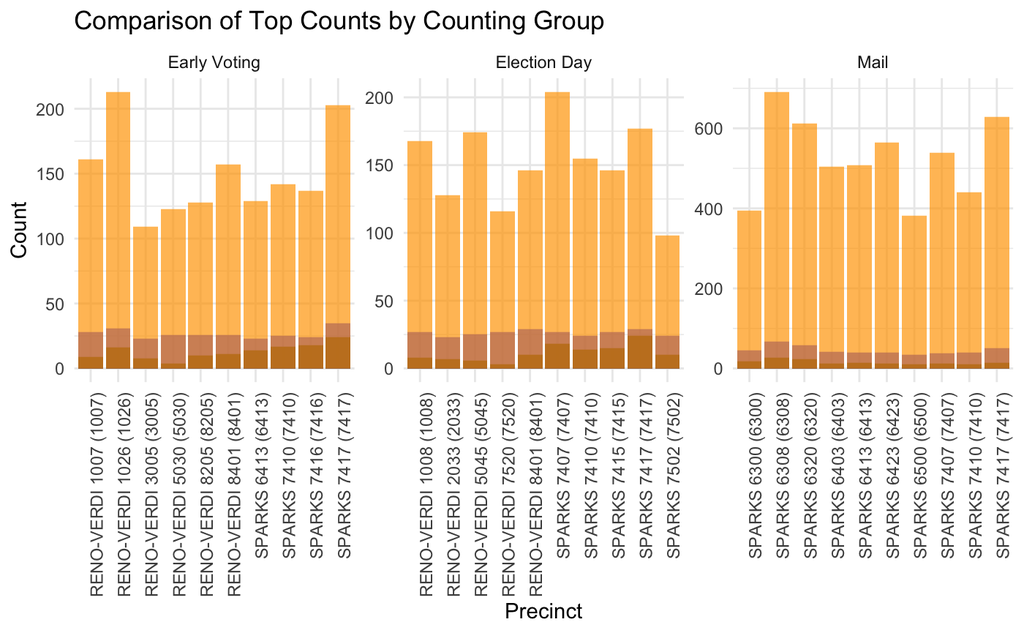

```r
library(ggplot2)

# Create separate plots faceted by CountingGroup
ggplot(comparison_table_all, aes(x = PrecinctPortion)) +
  geom_bar(aes(y = count_duplicates), stat = "identity", fill = "blue", alpha = 0.7)+
  geom_bar(aes(y = count_moreduplicates), stat = "identity", fill = "black", alpha = 0.7) +
  geom_bar(aes(y = count_all), stat = "identity", fill = "orange", alpha = 0.7) +

  facet_wrap(~ CountingGroup, scales = "free") +
  labs(title = "Comparison of Top Counts by Counting Group",
       x = "Precinct",
       y = "Count") +
  theme_minimal() +
  theme(axis.text.x = element_text(angle = 90, hjust = 1))  # Rotate labels by 45 degrees
```

To simplify understanding of the data, look at the difference and ratio of the duplicates to all counts.

```r
# Calculate differences
comparison_table$Difference <- comparison_table$count_all - comparison_table$count_duplicates

# Calculate ratios (assuming Count2 is not zero)
comparison_table$Ratio <- comparison_table$count_duplicates / comparison_table$count_all

# Arrange by smallest difference
comparison_table <- comparison_table %>%
  arrange(Difference)

# Display the updated dataset
#print(comparison_table)

# Split the data by CountingGroup
split_data_table2 <- split(comparison_table, comparison_table$CountingGroup)

# Print tables for each CountingGroup sorted by count in descending order
for (group in names(split_data_table2)) {
  cat("\nCounting Group:", group, "\n")
  sorted_table <- split_data_table2[[group]] %>%
    arrange(desc(Ratio))  # Sort by count column in descending order
  print(sorted_table)
  cat("\n")
}
```

```
Counting Group: Early Voting
```

| CountingGroup | PrecinctPortion | count_duplicates | count_all | Difference | Ratio |
| --- | --- | --- | --- | --- | --- |
| Early Voting | RENO-VERDI 5030 (5030) | 26 | 123 | 97 | 0.2113821 |
| Early Voting | RENO-VERDI 3005 (3005) | 23 | 109 | 86 | 0.2110092 |
| Early Voting | RENO-VERDI 8205 (8205) | 26 | 128 | 102 | 0.2031250 |
| Early Voting | SPARKS 6413 (6413) | 23 | 129 | 106 | 0.1782946 |
| Early Voting | SPARKS 7410 (7410) | 25 | 142 | 117 | 0.1760563 |
| Early Voting | SPARKS 7416 (7416) | 24 | 137 | 113 | 0.1751825 |
| Early Voting | RENO-VERDI 1007 (1007) | 28 | 161 | 133 | 0.1739130 |
| Early Voting | SPARKS 7417 (7417) | 35 | 203 | 168 | 0.1724138 |
| Early Voting | RENO-VERDI 8401 (8401) | 26 | 157 | 131 | 0.1656051 |
| Early Voting | RENO-VERDI 1026 (1026) | 31 | 213 | 182 | 0.1455399 |

| CountingGroup <chr> | PrecinctPortion <chr> | count_duplicates <int> | count_all <int> | Difference <int> | Ratio <dbl> |
| --- | --- | --- | --- | --- | --- |
| Early Voting | RENO-VERDI 5030 (5030) | 26 | 123 | 97 | 0.2113821 |
| Early Voting | RENO-VERDI 3005 (3005) | 23 | 109 | 86 | 0.2110092 |
| Early Voting | RENO-VERDI 8205 (8205) | 26 | 128 | 102 | 0.2031250 |
| Early Voting | SPARKS 6413 (6413) | 23 | 129 | 106 | 0.1782946 |
| Early Voting | SPARKS 7410 (7410) | 25 | 142 | 117 | 0.1760563 |
| Early Voting | SPARKS 7416 (7416) | 24 | 137 | 113 | 0.1751825 |
| Early Voting | RENO-VERDI 1007 (1007) | 28 | 161 | 133 | 0.1739130 |
| Early Voting | SPARKS 7417 (7417) | 35 | 203 | 168 | 0.1724138 |
| Early Voting | RENO-VERDI 8401 (8401) | 26 | 157 | 131 | 0.1656051 |
| Early Voting | RENO-VERDI 1026 (1026) | 31 | 213 | 182 | 0.1455399 |

1-10 of 10 rows

```
Counting Group: Election Day
```

| CountingGroup | PrecinctPortion | count_duplicates | count_all | Difference | Ratio |
| --- | --- | --- | --- | --- | --- |
| Election Day | SPARKS 7502 (7502) | 24 | 98 | 74 | 0.2448980 |
| Election Day | RENO-VERDI 7520 (7520) | 27 | 116 | 89 | 0.2327586 |
| Election Day | RENO-VERDI 8401 (8401) | 29 | 146 | 117 | 0.1986301 |
| Election Day | SPARKS 7415 (7415) | 27 | 146 | 119 | 0.1849315 |
| Election Day | RENO-VERDI 2033 (2033) | 23 | 128 | 105 | 0.1796875 |
| Election Day | SPARKS 7417 (7417) | 29 | 177 | 148 | 0.1638418 |
| Election Day | RENO-VERDI 1008 (1008) | 27 | 168 | 141 | 0.1607143 |
| Election Day | SPARKS 7410 (7410) | 24 | 155 | 131 | 0.1548387 |
| Election Day | RENO-VERDI 5045 (5045) | 25 | 174 | 149 | 0.1436782 |
| Election Day | SPARKS 7407 (7407) | 27 | 204 | 177 | 0.1323529 |

| CountingGroup <chr> | PrecinctPortion <chr> | count_duplicates <int> | count_all <int> | Difference <int> | Ratio <dbl> |
| --- | --- | --- | --- | --- | --- |
| Election Day | SPARKS 7502 (7502) | 24 | 98 | 74 | 0.2448980 |
| Election Day | RENO-VERDI 7520 (7520) | 27 | 116 | 89 | 0.2327586 |
| Election Day | RENO-VERDI 8401 (8401) | 29 | 146 | 117 | 0.1986301 |
| Election Day | SPARKS 7415 (7415) | 27 | 146 | 119 | 0.1849315 |
| Election Day | RENO-VERDI 2033 (2033) | 23 | 128 | 105 | 0.1796875 |
| Election Day | SPARKS 7417 (7417) | 29 | 177 | 148 | 0.1638418 |
| Election Day | RENO-VERDI 1008 (1008) | 27 | 168 | 141 | 0.1607143 |
| Election Day | SPARKS 7410 (7410) | 24 | 155 | 131 | 0.1548387 |
| Election Day | RENO-VERDI 5045 (5045) | 25 | 174 | 149 | 0.1436782 |
| Election Day | SPARKS 7407 (7407) | 27 | 204 | 177 | 0.1323529 |

1-10 of 10 rows

```
Counting Group: Mail
```

| CountingGroup | PrecinctPortion | count_duplicates | count_all | Difference | Ratio |
| --- | --- | --- | --- | --- | --- |
| Mail | SPARKS 6300 (6300) | 45 | 395 | 350 | 0.11392405 |
| Mail | SPARKS 6308 (6308) | 67 | 691 | 624 | 0.09696093 |
| Mail | SPARKS 6320 (6320) | 58 | 612 | 554 | 0.09477124 |
| Mail | SPARKS 6500 (6500) | 35 | 382 | 347 | 0.09162304 |
| Mail | SPARKS 7410 (7410) | 39 | 440 | 401 | 0.08863636 |
| Mail | SPARKS 6403 (6403) | 42 | 504 | 462 | 0.08333333 |
| Mail | SPARKS 7417 (7417) | 51 | 628 | 577 | 0.08121019 |
| Mail | SPARKS 6413 (6413) | 40 | 507 | 467 | 0.07889546 |
| Mail | SPARKS 6423 (6423) | 39 | 565 | 526 | 0.06902655 |
| Mail | SPARKS 7407 (7407) | 37 | 539 | 502 | 0.06864564 |

| CountingGroup <chr> | PrecinctPortion <chr> | count_duplicates <int> | count_all <int> | Difference <int> | Ratio <dbl> |
| --- | --- | --- | --- | --- | --- |
| Mail | SPARKS 6300 (6300) | 45 | 395 | 350 | 0.11392405 |
| Mail | SPARKS 6308 (6308) | 67 | 691 | 624 | 0.09696093 |
| Mail | SPARKS 6320 (6320) | 58 | 612 | 554 | 0.09477124 |
| Mail | SPARKS 6500 (6500) | 35 | 382 | 347 | 0.09162304 |
| Mail | SPARKS 7410 (7410) | 39 | 440 | 401 | 0.08863636 |
| Mail | SPARKS 6403 (6403) | 42 | 504 | 462 | 0.08333333 |
| Mail | SPARKS 7417 (7417) | 51 | 628 | 577 | 0.08121019 |
| Mail | SPARKS 6413 (6413) | 40 | 507 | 467 | 0.07889546 |
| Mail | SPARKS 6423 (6423) | 39 | 565 | 526 | 0.06902655 |
| Mail | SPARKS 7407 (7407) | 37 | 539 | 502 | 0.06864564 |

1-10 of 10 rows

```
NA
```

These numbers need to be broken down to account for the differences in ballot types.

```r
cvrballot <- cvr

# Use substr() to extract first two letters
cvrballot$BallotType <- substr(cvrballot$BallotType, 1, 2)

cvrballot <- cvrballot[, c("BallotType","CountingGroup", "PrecinctPortion", names(cvr)[17:ncol(cvr)])]

# Print the modified dataset
print(head(cvrballot))
```

| BallotType | CountingGroup | PrecinctPortion | ROSEN, JACKY S. | SCHAEFER, MIKE | WALKER, TROY ZAKARI | NONE OF THESE CANDIDATES...20 | BROWN, SAM | CONRAD, BILL "GREEN BERET" | GRADY, JR., WALTER A. "TONY" | GUNTER, JEFF | HAMILTON, E.T. "EDDYNOMICS" | KENNEDY, RONDA | LINDEMANN, BARRY CAMERON | MABEY, GARN | MARCHANT, JIM | MARINCH, GARY A. | PHILLIPS, STEPHANIE | REGO, VINCENT G. | NONE OF THESE CANDIDATES...33 | AMODEI, MARK E. | SIMON, JR., FRED J. "DOC" | DUERR, NAOMI | KERNS, JOHNNY | TAYLOR, ANGELA D. | ANGLE, SHARRON | GINSBURG, MIKE | NEUMANN, MARK | SAVAGE, SCOTT | SULLIVAN, DIANE "NEVADA MOON" | … |
| --- | --- | --- | --- | --- | --- | --- | --- | --- | --- | --- | --- | --- | --- | --- | --- | --- | --- | --- | --- | --- | --- | --- | --- | --- | --- | --- | --- | --- | --- | --- |
| DE | Mail | RENO-VERDI 2010 (2010) | 1 (85%) | 0 (0%) | 0 (0%) | 0 (0%) | NA | NA | NA | NA | NA | NA | NA | NA | NA | NA | NA | NA | NA | NA | NA | NA | NA | NA | NA | NA | NA | NA | NA | … |
| RE | Mail | RENO-VERDI 2010 (2010) | NA | NA | NA | NA | 1 (64%) | 0 (0%) | 0 (0%) | 0 (0%) | 0 (0%) | 0 (0%) | 0 (0%) | 0 (0%) | 0 (0%) | 0 (0%) | 0 (0%) | 0 (0%) | 0 (0%) | 1 (61%) | 0 (0%) | NA | NA | NA | NA | NA | NA | NA | NA | … |
| DE | Mail | RENO-VERDI 2010 (2010) | 1 (87%) | 0 (0%) | 0 (0%) | 0 (0%) | NA | NA | NA | NA | NA | NA | NA | NA | NA | NA | NA | NA | NA | NA | NA | NA | NA | NA | NA | NA | NA | NA | NA | … |
| RE | Mail | RENO-VERDI 2010 (2010) | NA | NA | NA | NA | 1 (96%) | 0 (0%) | 0 (0%) | 0 (0%) | 0 (0%) | 0 (0%) | 0 (0%) | 0 (0%) | 0 (0%) | 0 (0%) | 0 (0%) | 0 (0%) | 0 (0%) | 1 (94%) | 0 (0%) | NA | NA | NA | NA | NA | NA | NA | NA | … |
| DE | Mail | RENO-VERDI 2010 (2010) | 1 (99%) | 0 (0%) | 0 (0%) | 0 (0%) | NA | NA | NA | NA | NA | NA | NA | NA | NA | NA | NA | NA | NA | NA | NA | NA | NA | NA | NA | NA | NA | NA | NA | … |
| DE | Mail | RENO-VERDI 2010 (2010) | 1 (88%) | 0 (0%) | 0 (0%) | 0 (0%) | NA | NA | NA | NA | NA | NA | NA | NA | NA | NA | NA | NA | NA | NA | NA | NA | NA | NA | NA | NA | NA | NA | NA | … |

| BallotType <chr> | CountingGroup <chr> | PrecinctPortion <chr> | ROSEN, JACKY S. <chr> | SCHAEFER, MIKE <chr> |  |
| --- | --- | --- | --- | --- | --- |
| DE | Mail | RENO-VERDI 2010 (2010) | 1 (85%) | 0 (0%) |  |
| RE | Mail | RENO-VERDI 2010 (2010) | NA | NA |  |
| DE | Mail | RENO-VERDI 2010 (2010) | 1 (87%) | 0 (0%) |  |
| RE | Mail | RENO-VERDI 2010 (2010) | NA | NA |  |
| DE | Mail | RENO-VERDI 2010 (2010) | 1 (99%) | 0 (0%) |  |
| DE | Mail | RENO-VERDI 2010 (2010) | 1 (88%) | 0 (0%) |  |

6 rows | 1-5 of 110 columns

```r
#print(nrow(cvrballot))

all_ballots <- cvrballot %>%
  group_by(CountingGroup, PrecinctPortion, BallotType) %>%
  tally(name = "count")

# Split the data by CountingGroup
split_all_ballots <- split(all_ballots, all_ballots$CountingGroup)

unique_ballots_one <- cvrballot %>%
  group_by_all() %>%
  tally(name = "count") %>%
  filter(count > 1)

#print(nrow(unique_ballots_one))

grouped_ballots <- unique_ballots_one %>%
  group_by(CountingGroup, PrecinctPortion, BallotType) %>%
  tally(name = "count") %>%
  filter(count > 1)

# Split the data by CountingGroup
split_grouped_ballots <- split(grouped_ballots, grouped_ballots$CountingGroup)

# Identify top counts in the smaller set
top_counts_ballots <- grouped_ballots %>%
  arrange(desc(count)) %>%
  slice_head(n = 10)  # Example: Selecting top 10 counts, adjust as needed

# Match top counts with larger set
comparison_ballots <- top_counts_ballots %>%
  left_join(all_ballots, by = c("BallotType","CountingGroup", "PrecinctPortion"), suffix = c("_duplicates", "_all"))


# Split the data by CountingGroup
split_ballots <- split(comparison_ballots, comparison_ballots$CountingGroup)

# Print the comparison table
#print(comparison_ballots)

# Print tables for each CountingGroup sorted by count in descending order
for (group in names(split_ballots)) {
  cat("\nCounting Group:", group, "\n")
  sorted_table <- split_ballots[[group]] %>%
    arrange(desc(count_duplicates))  # Sort by count column in descending order
  print(sorted_table)
  cat("\n")
}
```

```
Counting Group: Early Voting
```

| CountingGroup | PrecinctPortion | BallotType | count_duplicates | count_all |
| --- | --- | --- | --- | --- |
| Early Voting | SPARKS 7417 (7417) | RE | 27 | 159 |
| Early Voting | RENO-VERDI 8205 (8205) | RE | 20 | 92 |
| Early Voting | RENO-VERDI 8401 (8401) | RE | 19 | 103 |
| Early Voting | SPARKS 7415 (7415) | RE | 19 | 134 |
| Early Voting | SPARKS 7416 (7416) | RE | 19 | 104 |
| Early Voting | RENO-VERDI 1007 (1007) | RE | 18 | 98 |
| Early Voting | SPARKS 7407 (7407) | RE | 18 | 111 |
| Early Voting | SPARKS 7410 (7410) | RE | 18 | 102 |
| Early Voting | SPARKS 6413 (6413) | RE | 17 | 90 |
| Early Voting | RENO-VERDI 8203 (8203) | RE | 16 | 70 |

[output cut: 296 more lines]

| CountingGroup <chr> | PrecinctPortion <chr> | BallotType <chr> | count_duplicates <int> | count_all <int> |
| --- | --- | --- | --- | --- |
| Early Voting | SPARKS 7417 (7417) | RE | 27 | 159 |
| Early Voting | RENO-VERDI 8205 (8205) | RE | 20 | 92 |
| Early Voting | RENO-VERDI 8401 (8401) | RE | 19 | 103 |
| Early Voting | SPARKS 7415 (7415) | RE | 19 | 134 |
| Early Voting | SPARKS 7416 (7416) | RE | 19 | 104 |
| Early Voting | RENO-VERDI 1007 (1007) | RE | 18 | 98 |
| Early Voting | SPARKS 7407 (7407) | RE | 18 | 111 |
| Early Voting | SPARKS 7410 (7410) | RE | 18 | 102 |
| Early Voting | SPARKS 6413 (6413) | RE | 17 | 90 |
| Early Voting | RENO-VERDI 8203 (8203) | RE | 16 | 70 |

Next

...

31

Previous

1-10 of 306 rows

```
Counting Group: Election Day
```

| CountingGroup | PrecinctPortion | BallotType | count_duplicates | count_all |
| --- | --- | --- | --- | --- |
| Election Day | RENO-VERDI 8401 (8401) | RE | 25 | 115 |
| Election Day | SPARKS 7417 (7417) | RE | 24 | 150 |
| Election Day | SPARKS 7415 (7415) | RE | 21 | 126 |
| Election Day | RENO-VERDI 7520 (7520) | RE | 20 | 80 |
| Election Day | SPARKS 7407 (7407) | RE | 20 | 177 |
| Election Day | RENO-VERDI 5045 (5045) | RE | 18 | 111 |
| Election Day | RENO-VERDI 2033 (2033) | RE | 17 | 88 |
| Election Day | SPARKS 6413 (6413) | RE | 17 | 105 |
| Election Day | SPARKS 7410 (7410) | RE | 17 | 121 |
| Election Day | RENO-VERDI 7525 (7525) | RE | 16 | 83 |

[output cut: 312 more lines]

| CountingGroup <chr> | PrecinctPortion <chr> | BallotType <chr> | count_duplicates <int> | count_all <int> |
| --- | --- | --- | --- | --- |
| Election Day | RENO-VERDI 8401 (8401) | RE | 25 | 115 |
| Election Day | SPARKS 7417 (7417) | RE | 24 | 150 |
| Election Day | SPARKS 7415 (7415) | RE | 21 | 126 |
| Election Day | RENO-VERDI 7520 (7520) | RE | 20 | 80 |
| Election Day | SPARKS 7407 (7407) | RE | 20 | 177 |
| Election Day | RENO-VERDI 5045 (5045) | RE | 18 | 111 |
| Election Day | RENO-VERDI 2033 (2033) | RE | 17 | 88 |
| Election Day | SPARKS 6413 (6413) | RE | 17 | 105 |
| Election Day | SPARKS 7410 (7410) | RE | 17 | 121 |
| Election Day | RENO-VERDI 7525 (7525) | RE | 16 | 83 |

Next

...

33

Previous

1-10 of 322 rows

```
Counting Group: Mail
```

| CountingGroup | PrecinctPortion | BallotType | count_duplicates | count_all |
| --- | --- | --- | --- | --- |
| Mail | SPARKS 6308 (6308) | DE | 41 | 312 |
| Mail | SPARKS 6320 (6320) | DE | 36 | 272 |
| Mail | SPARKS 6300 (6300) | DE | 33 | 226 |
| Mail | SPARKS 6403 (6403) | DE | 29 | 257 |
| Mail | SPARKS 7417 (7417) | DE | 27 | 192 |
| Mail | SPARKS 6308 (6308) | NP | 25 | 100 |
| Mail | SPARKS 7417 (7417) | NP | 23 | 86 |
| Mail | SPARKS 6423 (6423) | DE | 22 | 183 |
| Mail | SPARKS 7410 (7410) | DE | 21 | 185 |
| Mail | SPARKS 6413 (6413) | DE | 20 | 188 |

[output cut: 127 more lines]

| CountingGroup <chr> | PrecinctPortion <chr> | BallotType <chr> | count_duplicates <int> | count_all <int> |
| --- | --- | --- | --- | --- |
| Mail | SPARKS 6308 (6308) | DE | 41 | 312 |
| Mail | SPARKS 6320 (6320) | DE | 36 | 272 |
| Mail | SPARKS 6300 (6300) | DE | 33 | 226 |
| Mail | SPARKS 6403 (6403) | DE | 29 | 257 |
| Mail | SPARKS 7417 (7417) | DE | 27 | 192 |
| Mail | SPARKS 6308 (6308) | NP | 25 | 100 |
| Mail | SPARKS 7417 (7417) | NP | 23 | 86 |
| Mail | SPARKS 6423 (6423) | DE | 22 | 183 |
| Mail | SPARKS 7410 (7410) | DE | 21 | 185 |
| Mail | SPARKS 6413 (6413) | DE | 20 | 188 |

Next

...

14

Previous

1-10 of 137 rows

```
NA
```

```r
# Split dataset based on BallotType
split_data <- split(comparison_ballots, comparison_ballots$BallotType)

# Extract the individual datasets
data_re <- split_data[["RE"]]
data_de <- split_data[["DE"]]
data_np <- split_data[["NP"]]

# Verify the split (print first few rows of each)
print(data_re)
```

| CountingGroup | PrecinctPortion | BallotType | count_duplicates | count_all |
| --- | --- | --- | --- | --- |
| Early Voting | INCLINE VILLAGE 8104 (8104) | RE | 4 | 29 |
| Early Voting | INCLINE VILLAGE 8105 (8105) | RE | 2 | 20 |
| Early Voting | INCLINE VILLAGE 8106 (8106) | RE | 3 | 26 |
| Early Voting | INCLINE VILLAGE 8107 (8107) | RE | 3 | 24 |
| Early Voting | INCLINE VILLAGE 8108 (8108) | RE | 2 | 28 |
| Early Voting | INCLINE VILLAGE 8109 (8109) | RE | 4 | 31 |
| Early Voting | INCLINE VILLAGE 8116 (8116) | RE | 2 | 22 |
| Early Voting | INCLINE VILLAGE 8117 (8117) | RE | 4 | 33 |
| Early Voting | RENO-VERDI 1000 (1000) | RE | 2 | 27 |
| Early Voting | RENO-VERDI 1003 (1003) | RE | 2 | 18 |

[output cut: 310 more lines]

| CountingGroup <chr> | PrecinctPortion <chr> | BallotType <chr> | count_duplicates <int> | count_all <int> |
| --- | --- | --- | --- | --- |
| Early Voting | INCLINE VILLAGE 8104 (8104) | RE | 4 | 29 |
| Early Voting | INCLINE VILLAGE 8105 (8105) | RE | 2 | 20 |
| Early Voting | INCLINE VILLAGE 8106 (8106) | RE | 3 | 26 |
| Early Voting | INCLINE VILLAGE 8107 (8107) | RE | 3 | 24 |
| Early Voting | INCLINE VILLAGE 8108 (8108) | RE | 2 | 28 |
| Early Voting | INCLINE VILLAGE 8109 (8109) | RE | 4 | 31 |
| Early Voting | INCLINE VILLAGE 8116 (8116) | RE | 2 | 22 |
| Early Voting | INCLINE VILLAGE 8117 (8117) | RE | 4 | 33 |
| Early Voting | RENO-VERDI 1000 (1000) | RE | 2 | 27 |
| Early Voting | RENO-VERDI 1003 (1003) | RE | 2 | 18 |

Next

...

32

Previous

1-10 of 320 rows

```r
print(data_de)
```

| CountingGroup | PrecinctPortion | BallotType | count_duplicates | count_all |
| --- | --- | --- | --- | --- |
| Early Voting | GER-WADS 7561 (7561) | DE | 4 | 15 |
| Early Voting | GER-WADS 7581 (7581) | DE | 2 | 10 |
| Early Voting | INCLINE VILLAGE 8104 (8104) | DE | 3 | 18 |
| Early Voting | INCLINE VILLAGE 8105 (8105) | DE | 4 | 26 |
| Early Voting | INCLINE VILLAGE 8106 (8106) | DE | 4 | 17 |
| Early Voting | INCLINE VILLAGE 8108 (8108) | DE | 4 | 18 |
| Early Voting | INCLINE VILLAGE 8109 (8109) | DE | 6 | 24 |
| Early Voting | INCLINE VILLAGE 8116 (8116) | DE | 6 | 27 |
| Early Voting | INCLINE VILLAGE 8117 (8117) | DE | 4 | 19 |
| Early Voting | RENO-VERDI 1000 (1000) | DE | 8 | 53 |

[output cut: 308 more lines]

| CountingGroup <chr> | PrecinctPortion <chr> | BallotType <chr> | count_duplicates <int> | count_all <int> |
| --- | --- | --- | --- | --- |
| Early Voting | GER-WADS 7561 (7561) | DE | 4 | 15 |
| Early Voting | GER-WADS 7581 (7581) | DE | 2 | 10 |
| Early Voting | INCLINE VILLAGE 8104 (8104) | DE | 3 | 18 |
| Early Voting | INCLINE VILLAGE 8105 (8105) | DE | 4 | 26 |
| Early Voting | INCLINE VILLAGE 8106 (8106) | DE | 4 | 17 |
| Early Voting | INCLINE VILLAGE 8108 (8108) | DE | 4 | 18 |
| Early Voting | INCLINE VILLAGE 8109 (8109) | DE | 6 | 24 |
| Early Voting | INCLINE VILLAGE 8116 (8116) | DE | 6 | 27 |
| Early Voting | INCLINE VILLAGE 8117 (8117) | DE | 4 | 19 |
| Early Voting | RENO-VERDI 1000 (1000) | DE | 8 | 53 |

Next

...

32

Previous

1-10 of 318 rows

```r
print(data_np)
```

| CountingGroup | PrecinctPortion | BallotType | count_duplicates | count_all |
| --- | --- | --- | --- | --- |
| Early Voting | INCLINE VILLAGE 8109 (8109) | NP | 2 | 10 |
| Early Voting | INCLINE VILLAGE 8117 (8117) | NP | 2 | 10 |
| Early Voting | RENO-VERDI 1007 (1007) | NP | 2 | 16 |
| Early Voting | RENO-VERDI 1008 (1008) | NP | 3 | 21 |
| Early Voting | RENO-VERDI 1026 (1026) | NP | 2 | 15 |
| Early Voting | RENO-VERDI 2031 (2031) | NP | 3 | 9 |
| Early Voting | RENO-VERDI 2047 (2047) | NP | 2 | 10 |
| Early Voting | RENO-VERDI 2058 (2058) | NP | 2 | 7 |
| Early Voting | RENO-VERDI 3005 (3005) | NP | 3 | 11 |
| Early Voting | RENO-VERDI 3023 (3023) | NP | 2 | 9 |

[output cut: 117 more lines]

| CountingGroup <chr> | PrecinctPortion <chr> | BallotType <chr> | count_duplicates <int> | count_all <int> |
| --- | --- | --- | --- | --- |
| Early Voting | INCLINE VILLAGE 8109 (8109) | NP | 2 | 10 |
| Early Voting | INCLINE VILLAGE 8117 (8117) | NP | 2 | 10 |
| Early Voting | RENO-VERDI 1007 (1007) | NP | 2 | 16 |
| Early Voting | RENO-VERDI 1008 (1008) | NP | 3 | 21 |
| Early Voting | RENO-VERDI 1026 (1026) | NP | 2 | 15 |
| Early Voting | RENO-VERDI 2031 (2031) | NP | 3 | 9 |
| Early Voting | RENO-VERDI 2047 (2047) | NP | 2 | 10 |
| Early Voting | RENO-VERDI 2058 (2058) | NP | 2 | 7 |
| Early Voting | RENO-VERDI 3005 (3005) | NP | 3 | 11 |
| Early Voting | RENO-VERDI 3023 (3023) | NP | 2 | 9 |

Next

...

13

Previous

1-10 of 127 rows

These formulas further divide the data by CountingGroup for Republican Ballots.

```r
# Calculate proportion of DuplicateCount to TotalCount for each PrecinctPortion and CountingGroup
data_re_analysis <- data_re %>%
  group_by(PrecinctPortion, CountingGroup) %>%
  summarise(
    Proportion = sum(count_duplicates) / sum(count_all)
  )
data_re_mail <- data_re_analysis %>%
  filter(CountingGroup == "Mail") %>%
  arrange(desc(Proportion))
data_re_electionday <- data_re_analysis %>%
  filter(CountingGroup == "Election Day") %>%
  arrange(desc(Proportion))
data_re_early <- data_re_analysis %>%
  filter(CountingGroup == "Early Voting") %>%
  arrange(desc(Proportion))
```

These formulas further divide the data by CountingGroup for Democratic Ballots.

```r
# Calculate proportion of DuplicateCount to TotalCount for each PrecinctPortion and CountingGroup
data_de_analysis <- data_de %>%
  group_by(PrecinctPortion, CountingGroup) %>%
  summarise(
    Proportion = sum(count_duplicates) / sum(count_all)
  )
data_de_mail <- data_de_analysis %>%
  filter(CountingGroup == "Mail") %>%
  arrange(desc(Proportion))
data_de_electionday <- data_de_analysis %>%
  filter(CountingGroup == "Election Day") %>%
  arrange(desc(Proportion))
data_de_early <- data_de_analysis %>%
  filter(CountingGroup == "Early Voting") %>%
  arrange(desc(Proportion))
```

These formulas further divide the data by CountingGroup for Non Partisan Ballots.

```r
# Calculate proportion of DuplicateCount to TotalCount for each PrecinctPortion and CountingGroup
data_np_analysis <- data_np %>%
  group_by(PrecinctPortion, CountingGroup) %>%
  summarise(
    Proportion = sum(count_duplicates) / sum(count_all)
  )
data_np_mail <- data_np_analysis %>%
  filter(CountingGroup == "Mail") %>%
  arrange(desc(Proportion))
data_np_electionday <- data_np_analysis %>%
  filter(CountingGroup == "Election Day") %>%
  arrange(desc(Proportion))
data_np_early <- data_np_analysis %>%
  filter(CountingGroup == "Early Voting") %>%
  arrange(desc(Proportion))
```

This directly compares republican and democratic ballots. Since nonpartisan ballots are fewer in number, there is a greater chance for skewed results if they are included.

```r
# Remove the CountingGroup column
# Rename Proportion columns
data1_re_mail <- data_re_mail %>%
  rename(proportion_re_mail = Proportion) %>%
  select(-CountingGroup)

data1_de_mail <- data_de_mail %>%
  rename(proportion_de_mail = Proportion) %>%
  select(-CountingGroup)

#data1_np_mail <- data_np_mail %>%
  #rename(proportion_np_mail = Proportion) %>%
  #select(-CountingGroup)

# Perform full joins
joined_rede_data_mail <- data1_re_mail %>%
  full_join(data1_de_mail, by = "PrecinctPortion")

# Define a threshold for significant difference
# this is an arbitrary threshold, replace with a true number
# this threshold looks at differences greater than 10%
threshold <- 0.1

# Create a function to check for significant differences
check_difference <- function(re, de, threshold) {
  differences <- abs(re - de) > threshold
  return(differences)
}

# Apply the function to the joined data and filter for significant differences
significant_differences_rede_mail <- joined_rede_data_mail %>%
  rowwise() %>%
  mutate(SignificantDifference = check_difference(proportion_re_mail, proportion_de_mail, threshold)) %>%
  filter(SignificantDifference == TRUE)

# Print the filtered data with significant differences
print(significant_differences_rede_mail)
```

| PrecinctPortion | proportion_re_mail | proportion_de_mail | SignificantDifference |
| --- | --- | --- | --- |
| SPARKS 6423 (6423) | 0.01812689 | 0.1202186 | TRUE |
| SPARKS 6320 (6320) | 0.01646091 | 0.1323529 | TRUE |
| SPARKS 6524 (6524) | 0.01075269 | 0.1208054 | TRUE |

| PrecinctPortion <chr> | proportion_re_mail <dbl> | proportion_de_mail <dbl> | SignificantDifference <lgl> |  |
| --- | --- | --- | --- | --- |
| SPARKS 6423 (6423) | 0.01812689 | 0.1202186 | TRUE |  |
| SPARKS 6320 (6320) | 0.01646091 | 0.1323529 | TRUE |  |
| SPARKS 6524 (6524) | 0.01075269 | 0.1208054 | TRUE |  |

3 rows

```r
print(nrow(significant_differences_rede_mail)/nrow(joined_rede_data_mail))
```

```
[1] 0.04109589
```

Sparks 6308 is nowhere to be found. This means that there is no significant difference between the proportion of democratic duplicate voting patterns to republican voting patterns. Even though it was the counting group and precinct with the greatest number of duplicate voting patterns, there is no significant difference between ballot types.

```r
# to do the analysis with np ballots included, here is the code:

# joined_data <- data_re_mail %>%
# full_join(data_de_mail, by = "PrecinctPortion") %>%
 #full_join(data_np_mail, by = "PrecinctPortion")

# Create a function to check for significant differences
# check_difference <- function(re, de, np, threshold) {
  # differences <- abs(re - de) > threshold | abs(re - np) > threshold | abs(de - np) > threshold
  # return(differences)
```

```r
# Remove the CountingGroup column
# Rename Proportion columns
data1_re_electionday <- data_re_electionday %>%
  rename(proportion_re_electionday = Proportion) %>%
  select(-CountingGroup)

data1_de_electionday <- data_de_electionday %>%
  rename(proportion_de_electionday = Proportion) %>%
  select(-CountingGroup)

#data1_np_electionday <- data_np_electionday %>%
  #rename(proportion_np_electionday = Proportion) %>%
  #select(-CountingGroup)

# Perform full joins
joined_rede_data_electionday <- data1_re_electionday %>%
  full_join(data1_de_electionday, by = "PrecinctPortion")

# Define a threshold for significant difference
# this is an arbitrary threshold, replace with a true number
# this threshold looks at differences greater than 10%
threshold <- 0.1

# Create a function to check for significant differences
check_difference <- function(re, de, threshold) {
  differences <- abs(re - de) > threshold
  return(differences)
}

# Apply the function to the joined data and filter for significant differences
significant_differences_rede_electionday <- joined_rede_data_electionday %>%
  rowwise() %>%
  mutate(SignificantDifference = check_difference(proportion_re_electionday, proportion_de_electionday, threshold)) %>%
  filter(SignificantDifference == TRUE)

# Print the filtered data with significant differences
print(significant_differences_rede_electionday)
```

| PrecinctPortion | proportion_re_electionday | proportion_de_electionday | SignificantDifference |
| --- | --- | --- | --- |
| RENO-VERDI 3026 (3026) | 0.42857143 | 0.2857143 | TRUE |
| SPARKS 6306 (6306) | 0.31578947 | 0.1818182 | TRUE |
| SPARKS 6111 (6111) | 0.29032258 | 0.1428571 | TRUE |
| SPARKS 6110 (6110) | 0.28947368 | 0.1176471 | TRUE |
| SPARKS 6300 (6300) | 0.23255814 | 0.1250000 | TRUE |
| SPARKS 6416 (6416) | 0.22222222 | 0.4285714 | TRUE |
| RENO-VERDI 8401 (8401) | 0.21739130 | 0.1034483 | TRUE |
| RENO-VERDI 4019 (4019) | 0.18181818 | 0.2857143 | TRUE |
| SPARKS 6202 (6202) | 0.18181818 | 0.4000000 | TRUE |
| SPARKS 7402 (7402) | 0.17857143 | 0.3333333 | TRUE |

[output cut: 9 more lines]

| PrecinctPortion <chr> | proportion_re_electionday <dbl> | proportion_de_electionday <dbl> |  |
| --- | --- | --- | --- |
| RENO-VERDI 3026 (3026) | 0.42857143 | 0.2857143 |  |
| SPARKS 6306 (6306) | 0.31578947 | 0.1818182 |  |
| SPARKS 6111 (6111) | 0.29032258 | 0.1428571 |  |
| SPARKS 6110 (6110) | 0.28947368 | 0.1176471 |  |
| SPARKS 6300 (6300) | 0.23255814 | 0.1250000 |  |
| SPARKS 6416 (6416) | 0.22222222 | 0.4285714 |  |
| RENO-VERDI 8401 (8401) | 0.21739130 | 0.1034483 |  |
| RENO-VERDI 4019 (4019) | 0.18181818 | 0.2857143 |  |
| SPARKS 6202 (6202) | 0.18181818 | 0.4000000 |  |
| SPARKS 7402 (7402) | 0.17857143 | 0.3333333 |  |

Next

Previous

1-10 of 19 rows | 1-3 of 4 columns

```r
print(nrow(significant_differences_rede_electionday)/nrow(joined_rede_data_electionday))
```

```
[1] 0.1117647
```

```r
# Remove the CountingGroup column
# Rename Proportion columns
data1_re_early <- data_re_early %>%
  rename(proportion_re_early = Proportion) %>%
  select(-CountingGroup)

data1_de_early <- data_de_early %>%
  rename(proportion_de_early = Proportion) %>%
  select(-CountingGroup)

#data1_np_early <- data_np_early %>%
  #rename(proportion_np_early = Proportion) %>%
  #select(-CountingGroup)

# Perform full joins
joined_rede_data_early <- data1_re_early %>%
  full_join(data1_de_early, by = "PrecinctPortion")

# Define a threshold for significant difference
# this is an arbitrary threshold, replace with a true number
# this threshold looks at differences greater than 10%
threshold <- 0.1

# Create a function to check for significant differences
check_difference <- function(re, de, threshold) {
  differences <- abs(re - de) > threshold
  return(differences)
}

# Apply the function to the joined data and filter for significant differences
significant_differences_rede_early <- joined_rede_data_early %>%
  rowwise() %>%
  mutate(SignificantDifference = check_difference(proportion_re_early, proportion_de_early, threshold)) %>%
  filter(SignificantDifference == TRUE)

# Print the filtered data with significant differences
print(significant_differences_rede_early)
```

| PrecinctPortion | proportion_re_early | proportion_de_early | SignificantDifference |
| --- | --- | --- | --- |
| SPARKS 6307 (6307) | 0.33333333 | 0.2083333 | TRUE |
| RENO-VERDI 2058 (2058) | 0.29545455 | 0.1785714 | TRUE |
| SPARKS 6516 (6516) | 0.29032258 | 0.1363636 | TRUE |
| SPARKS 6110 (6110) | 0.28571429 | 0.1578947 | TRUE |
| SPARKS 6213 (6213) | 0.27586207 | 0.1250000 | TRUE |
| SPARKS 6211 (6211) | 0.23076923 | 0.1290323 | TRUE |
| SPARKS 6523 (6523) | 0.21428571 | 0.3333333 | TRUE |
| RENO-VERDI 8103 (8103) | 0.20000000 | 0.3333333 | TRUE |
| RENO-VERDI 8271 (8271) | 0.20000000 | 0.4285714 | TRUE |
| RENO-VERDI 4003 (4003) | 0.18181818 | 0.3333333 | TRUE |

[output cut: 10 more lines]

| PrecinctPortion <chr> | proportion_re_early <dbl> | proportion_de_early <dbl> | SignificantDifference <lgl> |
| --- | --- | --- | --- |
| SPARKS 6307 (6307) | 0.33333333 | 0.2083333 | TRUE |
| RENO-VERDI 2058 (2058) | 0.29545455 | 0.1785714 | TRUE |
| SPARKS 6516 (6516) | 0.29032258 | 0.1363636 | TRUE |
| SPARKS 6110 (6110) | 0.28571429 | 0.1578947 | TRUE |
| SPARKS 6213 (6213) | 0.27586207 | 0.1250000 | TRUE |
| SPARKS 6211 (6211) | 0.23076923 | 0.1290323 | TRUE |
| SPARKS 6523 (6523) | 0.21428571 | 0.3333333 | TRUE |
| RENO-VERDI 8103 (8103) | 0.20000000 | 0.3333333 | TRUE |
| RENO-VERDI 8271 (8271) | 0.20000000 | 0.4285714 | TRUE |
| RENO-VERDI 4003 (4003) | 0.18181818 | 0.3333333 | TRUE |

Next

Previous

1-10 of 20 rows

```r
print(nrow(significant_differences_rede_early)/nrow(joined_rede_data_early))
```

```
[1] 0.1219512
```

Keep in mind: In local and state elections, the level of variation in voting patterns can vary based on several factors:

Candidate Diversity: If there are multiple candidates running within the party, voters may exhibit varying degrees of preference based on candidate qualifications, policies, or personal connections.

Issues at Stake: The importance and nature of the issues being addressed in the election can influence voting patterns. Voters may prioritize different aspects of the party’s platform or agenda.

Campaign Dynamics: The effectiveness of candidate campaigns, endorsements, and outreach efforts can influence voter decisions. Strong campaigns may lead to more cohesive voting patterns, while weaker campaigns may result in more varied outcomes.

Demographics: The demographic composition of the electorate within the party can play a role. Different age groups, socioeconomic backgrounds, and geographic locations may have varying priorities and voting behaviors.

Party Unity: The level of unity or division within the party itself can impact voting patterns. In cases where the party is deeply divided on certain issues or candidates, there may be more variability in voting choices.

Historical Context: Previous election results and historical voting patterns within the party can provide context for understanding typical levels of variation. Changes in voter sentiment or party dynamics over time can also influence variation.

Typically, in local elections within one party, some level of variation in voting patterns is expected due to the diversity of opinions, preferences, and individual considerations among voters. However, the extent of this variation can vary widely depending on the specific circumstances of the election, including the factors mentioned above. Analyzing past election results and conducting voter surveys or focus groups can provide further insights into the typical variation expected in such elections.

The numbers demonstrate normal variation and a normal amount of duplicate voting patterns given the circumstances of the election.

~~~~~~~~~~~~~~~~~~~~~~~~~~~~~~~~~~~~~~~~~~~~~~~~~~~~~~~~~~~~~~~~~~~~~~~~~~~~~~~~ UNDERVOTES

```r
# Example assuming some structure similar to your dataset
# Replace column names and types as per your actual dataset structure

subset_undervote_cvr <- subset_cvr

# Example assuming some structure similar to your dataset
# Replace column names and types as per your actual dataset structure

# Clean and count undervotes
undervotes_count <- sapply(subset_undervote_cvr[, -(1:2)], function(x) {
  # Convert to character to handle factors
  x <- as.character(x)

  # Remove any non-numeric characters and convert to numeric
  x <- as.numeric(gsub("[^0-9.-]", "", x))  # Remove non-numeric characters

  # Count undervotes (excluding NA values)
  sum(x == 0 & !is.na(x))
})

# Print the counts of undervotes for each candidate column
#print(undervotes_count)

# Example assuming structure similar to your dataset
# Replace with actual dataset name and column indexing as needed

# Extract candidate names from the first row of subset_cvr
candidate_names <- names(subset_undervote_cvr)[-(1:2)]  # Assuming columns 1 and 2 are not candidates

# Print the vector of candidate names
#print(candidate_names)

# Example: Create a data frame with candidate names and their undervote counts
undervotes_table <- data.frame(Candidate = candidate_names, Undervotes = undervotes_count)

# Print the table
print(undervotes_table)
```

|  | Candidate | Undervotes |
| --- | --- | --- |
| ROSEN, JACKY S. | ROSEN, JACKY S. | 2331 |
| SCHAEFER, MIKE | SCHAEFER, MIKE | 33302 |
| WALKER, TROY ZAKARI | WALKER, TROY ZAKARI | 32675 |
| NONE OF THESE CANDIDATES...20 | NONE OF THESE CANDIDATES...20 | 33152 |
| BROWN, SAM | BROWN, SAM | 12447 |
| CONRAD, BILL "GREEN BERET" | CONRAD, BILL "GREEN BERET" | 34498 |
| GRADY, JR., WALTER A. "TONY" | GRADY, JR., WALTER A. "TONY" | 33140 |
| GUNTER, JEFF | GUNTER, JEFF | 31980 |
| HAMILTON, E.T. "EDDYNOMICS" | HAMILTON, E.T. "EDDYNOMICS" | 35425 |
| KENNEDY, RONDA | KENNEDY, RONDA | 35157 |

[output cut: 97 more lines]

|  | Candidate <chr> | Undervotes <int> |  |  |
| --- | --- | --- | --- | --- |
| ROSEN, JACKY S. | ROSEN, JACKY S. | 2331 |  |  |
| SCHAEFER, MIKE | SCHAEFER, MIKE | 33302 |  |  |
| WALKER, TROY ZAKARI | WALKER, TROY ZAKARI | 32675 |  |  |
| NONE OF THESE CANDIDATES...20 | NONE OF THESE CANDIDATES...20 | 33152 |  |  |
| BROWN, SAM | BROWN, SAM | 12447 |  |  |
| CONRAD, BILL "GREEN BERET" | CONRAD, BILL "GREEN BERET" | 34498 |  |  |
| GRADY, JR., WALTER A. "TONY" | GRADY, JR., WALTER A. "TONY" | 33140 |  |  |
| GUNTER, JEFF | GUNTER, JEFF | 31980 |  |  |
| HAMILTON, E.T. "EDDYNOMICS" | HAMILTON, E.T. "EDDYNOMICS" | 35425 |  |  |
| KENNEDY, RONDA | KENNEDY, RONDA | 35157 |  |  |

Next

...

11

Previous

1-10 of 107 rows

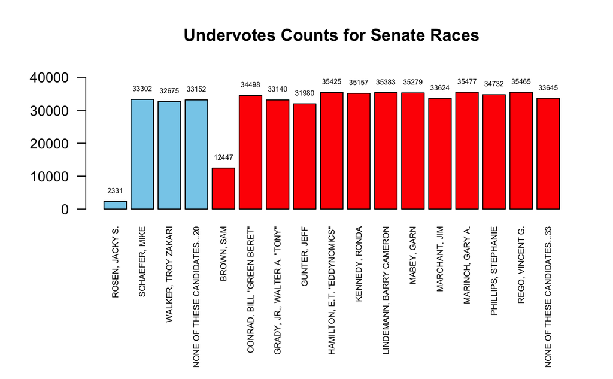

```r
# Subset the first four candidates (democratic senate race)
undervotes_subset_senate <- undervotes_table[1:17, ]

candidates <- paste("Candidate", 1:17, sep = "")

# Create a bar plot
par(mar = c(10, 5, 4, 2) + 0.1)  # Adjust margins for better spacing
barplot(undervotes_subset_senate$Undervotes, names.arg = undervotes_subset_senate$Candidate,
        main = "Undervotes Counts for Senate Races",
        col = ifelse(seq_along(candidates) >= 5, "red", "skyblue"),
        ylim = c(0, max(undervotes_subset_senate$Undervotes) * 1.2),
        las = 2, cex.names = 0.6)  # Rotate x-axis labels if necessary

# Add text labels inside each bar
text(x = barplot(undervotes_subset_senate$Undervotes, plot = FALSE),  # Get x-coordinates of bars
     y = undervotes_subset_senate$Undervotes,   # Use undervotes counts for y-coordinates
     labels = undervotes_subset_senate$Undervotes,  # Labels to display inside bars
     pos = 3,   # Position text above each bar
     cex = 0.5,   # Adjust font size of labels
     col = "black")   # Color of text labels
```

```r
undervotes_subset_senate <- undervotes_table[1:17, ]

undervotes_subset_repdist2 <- undervotes_table[18:19, ]
  print(undervotes_subset_repdist2)
```

|  | Candidate | Undervotes |
| --- | --- | --- |
| AMODEI, MARK E. | AMODEI, MARK E. | 12640 |
| SIMON, JR., FRED J. "DOC" | SIMON, JR., FRED J. "DOC" | 24163 |

|  | Candidate <chr> | Undervotes <int> |  |  |
| --- | --- | --- | --- | --- |
| AMODEI, MARK E. | AMODEI, MARK E. | 12640 |  |  |
| SIMON, JR., FRED J. "DOC" | SIMON, JR., FRED J. "DOC" | 24163 |  |  |

2 rows

```r
undervotes_subset_stsen15 <- undervotes_table[20:25, ]
  print(undervotes_subset_stsen15)
```

|  | Candidate | Undervotes |
| --- | --- | --- |
| DUERR, NAOMI | DUERR, NAOMI | 7733 |
| KERNS, JOHNNY | KERNS, JOHNNY | 11292 |
| TAYLOR, ANGELA D. | TAYLOR, ANGELA D. | 4313 |
| ANGLE, SHARRON | ANGLE, SHARRON | 5273 |
| GINSBURG, MIKE | GINSBURG, MIKE | 4531 |
| NEUMANN, MARK | NEUMANN, MARK | 8154 |

|  | Candidate <chr> | Undervotes <int> |  |  |
| --- | --- | --- | --- | --- |
| DUERR, NAOMI | DUERR, NAOMI | 7733 |  |  |
| KERNS, JOHNNY | KERNS, JOHNNY | 11292 |  |  |
| TAYLOR, ANGELA D. | TAYLOR, ANGELA D. | 4313 |  |  |
| ANGLE, SHARRON | ANGLE, SHARRON | 5273 |  |  |
| GINSBURG, MIKE | GINSBURG, MIKE | 4531 |  |  |
| NEUMANN, MARK | NEUMANN, MARK | 8154 |  |  |

6 rows

```r
undervotes_subset_stass26 <- undervotes_table[26:27, ]
  print(undervotes_subset_stass26)
```

|  | Candidate | Undervotes |
| --- | --- | --- |
| SAVAGE, SCOTT | SAVAGE, SCOTT | 4227 |
| SULLIVAN, DIANE "NEVADA MOON" | SULLIVAN, DIANE "NEVADA MOON" | 3097 |

|  | Candidate <chr> | Undervotes <int> |  |  |
| --- | --- | --- | --- | --- |
| SAVAGE, SCOTT | SAVAGE, SCOTT | 4227 |  |  |
| SULLIVAN, DIANE "NEVADA MOON" | SULLIVAN, DIANE "NEVADA MOON" | 3097 |  |  |

2 rows

```r
undervotes_subset_stass27 <- undervotes_table[28:29, ]
  print(undervotes_subset_stass27)
```

|  | Candidate | Undervotes |
| --- | --- | --- |
| GOULDING, HEATHER | GOULDING, HEATHER | 1959 |
| VELTO, ALEX | VELTO, ALEX | 2458 |

|  | Candidate <chr> | Undervotes <int> |  |  |
| --- | --- | --- | --- | --- |
| GOULDING, HEATHER | GOULDING, HEATHER | 1959 |  |  |
| VELTO, ALEX | VELTO, ALEX | 2458 |  |  |

2 rows

```r
undervotes_subset_stass32 <- undervotes_table[30:31, ]
  print(undervotes_subset_stass32)
```

|  | Candidate | Undervotes |
| --- | --- | --- |
| BUSHEY, JASON | BUSHEY, JASON | 3218 |
| HANSEN, ALEXIS M. | HANSEN, ALEXIS M. | 1505 |

|  | Candidate <chr> | Undervotes <int> |  |  |
| --- | --- | --- | --- | --- |
| BUSHEY, JASON | BUSHEY, JASON | 3218 |  |  |
| HANSEN, ALEXIS M. | HANSEN, ALEXIS M. | 1505 |  |  |

2 rows

```r
undervotes_subset_stass40 <- undervotes_table[32:33, ]
  print(undervotes_subset_stass40)
```

|  | Candidate | Undervotes |
| --- | --- | --- |
| O'NEILL, PHILIP "PK" | O'NEILL, PHILIP "PK" | 552 |
| RIBAR, DREW | RIBAR, DREW | 1327 |

|  | Candidate <chr> | Undervotes <int> |  |  |
| --- | --- | --- | --- | --- |
| O'NEILL, PHILIP "PK" | O'NEILL, PHILIP "PK" | 552 |  |  |
| RIBAR, DREW | RIBAR, DREW | 1327 |  |  |

2 rows

```r
undervotes_subset_cc1 <- undervotes_table[35:36, ]
  print(undervotes_subset_cc1)
```

|  | Candidate | Undervotes |
| --- | --- | --- |
| FITCH, MELISSA | FITCH, MELISSA | 6617 |
| HOOVER, EUGENE E. | HOOVER, EUGENE E. | 4900 |

|  | Candidate <chr> | Undervotes <int> |  |  |
| --- | --- | --- | --- | --- |
| FITCH, MELISSA | FITCH, MELISSA | 6617 |  |  |
| HOOVER, EUGENE E. | HOOVER, EUGENE E. | 4900 |  |  |

2 rows

```r
undervotes_subset_cc4 <- undervotes_table[37:41, ]
  print(undervotes_subset_cc4)
```

|  | Candidate | Undervotes |
| --- | --- | --- |
| ANDRIOLA, CLARA | ANDRIOLA, CLARA | 0 |
| GOMEZ, TRISTA | GOMEZ, TRISTA | 0 |
| HILTON-THOMAS, TRACEY | HILTON-THOMAS, TRACEY | 0 |
| LAWSON, MARK A. | LAWSON, MARK A. | 0 |
| WALTER, II, JOHN L. "LITTLE JOHN" | WALTER, II, JOHN L. "LITTLE JOHN" | 0 |

|  | Candidate <chr> | Undervotes <int> |  |  |
| --- | --- | --- | --- | --- |
| ANDRIOLA, CLARA | ANDRIOLA, CLARA | 0 |  |  |
| GOMEZ, TRISTA | GOMEZ, TRISTA | 0 |  |  |
| HILTON-THOMAS, TRACEY | HILTON-THOMAS, TRACEY | 0 |  |  |
| LAWSON, MARK A. | LAWSON, MARK A. | 0 |  |  |
| WALTER, II, JOHN L. "LITTLE JOHN" | WALTER, II, JOHN L. "LITTLE JOHN" | 0 |  |  |

5 rows

```r
undervotes_subset_edu2 <- undervotes_table[42:45, ]
  print(undervotes_subset_edu2)
```

|  | Candidate | Undervotes |
| --- | --- | --- |
| BUEHLER, MATTHEW R. | BUEHLER, MATTHEW R. | 66445 |
| DAVIS, PAUL "DOC" | DAVIS, PAUL "DOC" | 66506 |
| KING, JR., DORZELL | KING, JR., DORZELL | 73672 |
| ORR, ANGELA | ORR, ANGELA | 44725 |

|  | Candidate <chr> | Undervotes <int> |  |  |
| --- | --- | --- | --- | --- |
| BUEHLER, MATTHEW R. | BUEHLER, MATTHEW R. | 66445 |  |  |
| DAVIS, PAUL "DOC" | DAVIS, PAUL "DOC" | 66506 |  |  |
| KING, JR., DORZELL | KING, JR., DORZELL | 73672 |  |  |
| ORR, ANGELA | ORR, ANGELA | 44725 |  |  |

4 rows

```r
undervotes_subset_un9 <- undervotes_table[46:48, ]
  print(undervotes_subset_un9)
```

|  | Candidate | Undervotes |
| --- | --- | --- |
| DEL CARLO, CAROL L. | DEL CARLO, CAROL L. | 4770 |
| DELAIRE, BRET E. | DELAIRE, BRET E. | 7329 |
| JOHNSON, GARY T. | JOHNSON, GARY T. | 7775 |

|  | Candidate <chr> | Undervotes <int> |  |  |
| --- | --- | --- | --- | --- |
| DEL CARLO, CAROL L. | DEL CARLO, CAROL L. | 4770 |  |  |
| DELAIRE, BRET E. | DELAIRE, BRET E. | 7329 |  |  |
| JOHNSON, GARY T. | JOHNSON, GARY T. | 7775 |  |  |

3 rows

```r
undervotes_subset_sctrustA <- undervotes_table[49:51, ]
  print(undervotes_subset_sctrustA)
```

|  | Candidate | Undervotes |
| --- | --- | --- |
| CHURCH, J.D. | CHURCH, J.D. | 14989 |
| FLORES, STEPHANIE H. | FLORES, STEPHANIE H. | 19053 |
| HULL, CHRISTINE | HULL, CHRISTINE | 11036 |

|  | Candidate <chr> | Undervotes <int> |  |  |
| --- | --- | --- | --- | --- |
| CHURCH, J.D. | CHURCH, J.D. | 14989 |  |  |
| FLORES, STEPHANIE H. | FLORES, STEPHANIE H. | 19053 |  |  |
| HULL, CHRISTINE | HULL, CHRISTINE | 11036 |  |  |

3 rows

```r
undervotes_subset_sctrustD <- undervotes_table[52:56, ]
  print(undervotes_subset_sctrustD)
```

|  | Candidate | Undervotes |
| --- | --- | --- |
| COLE, JOSHUA | COLE, JOSHUA | 15243 |
| DREHER, RONALD P. | DREHER, RONALD P. | 15552 |
| MYER, VICTORIA | MYER, VICTORIA | 14481 |
| SMITH, BETH | SMITH, BETH | 7280 |
| TABAREZ, CHRIS | TABAREZ, CHRIS | 15360 |

|  | Candidate <chr> | Undervotes <int> |  |  |
| --- | --- | --- | --- | --- |
| COLE, JOSHUA | COLE, JOSHUA | 15243 |  |  |
| DREHER, RONALD P. | DREHER, RONALD P. | 15552 |  |  |
| MYER, VICTORIA | MYER, VICTORIA | 14481 |  |  |
| SMITH, BETH | SMITH, BETH | 7280 |  |  |
| TABAREZ, CHRIS | TABAREZ, CHRIS | 15360 |  |  |

5 rows

```r
undervotes_subset_sctrustE <- undervotes_table[57:60, ]
  print(undervotes_subset_sctrustE)
```

|  | Candidate | Undervotes |
| --- | --- | --- |
| KRAMER, CAMERON | KRAMER, CAMERON | 13131 |
| STENEHJEM, BEV | STENEHJEM, BEV | 9932 |
| WILLIAMS, OSCAR D. | WILLIAMS, OSCAR D. | 13036 |
| WOODLEY, ALEX C. | WOODLEY, ALEX C. | 7475 |

|  | Candidate <chr> | Undervotes <int> |  |  |
| --- | --- | --- | --- | --- |
| KRAMER, CAMERON | KRAMER, CAMERON | 13131 |  |  |
| STENEHJEM, BEV | STENEHJEM, BEV | 9932 |  |  |
| WILLIAMS, OSCAR D. | WILLIAMS, OSCAR D. | 13036 |  |  |
| WOODLEY, ALEX C. | WOODLEY, ALEX C. | 7475 |  |  |

4 rows

```r
undervotes_subset_sctrustG <- undervotes_table[61:67, ]
  print(undervotes_subset_sctrustG)
```

|  | Candidate | Undervotes |
| --- | --- | --- |
| DI CARLO, JACQLYN | DI CARLO, JACQLYN | 41707 |
| LEHMANN, MONICA | LEHMANN, MONICA | 41035 |
| NICOLET, DIANE | NICOLET, DIANE | 37547 |
| PHILLIPPS, NATHANIEL "NATE" | PHILLIPPS, NATHANIEL "NATE" | 42496 |
| ROSENSTEIN, PERRY | ROSENSTEIN, PERRY | 30980 |
| WHITE, PAUL D. | WHITE, PAUL D. | 39889 |
| WOO, ALICIA | WOO, ALICIA | 38631 |

|  | Candidate <chr> | Undervotes <int> |  |  |
| --- | --- | --- | --- | --- |
| DI CARLO, JACQLYN | DI CARLO, JACQLYN | 41707 |  |  |
| LEHMANN, MONICA | LEHMANN, MONICA | 41035 |  |  |
| NICOLET, DIANE | NICOLET, DIANE | 37547 |  |  |
| PHILLIPPS, NATHANIEL "NATE" | PHILLIPPS, NATHANIEL "NATE" | 42496 |  |  |
| ROSENSTEIN, PERRY | ROSENSTEIN, PERRY | 30980 |  |  |
| WHITE, PAUL D. | WHITE, PAUL D. | 39889 |  |  |
| WOO, ALICIA | WOO, ALICIA | 38631 |  |  |

7 rows

```r
undervotes_subset_reno1 <- undervotes_table[68:75, ]
  print(undervotes_subset_reno1)
```

|  | Candidate | Undervotes |
| --- | --- | --- |
| BARAN, LILY | BARAN, LILY | 2903 |
| DEMARTINI, MATTHEW | DEMARTINI, MATTHEW | 3548 |
| FREEMAN, DARRIN | FREEMAN, DARRIN | 3636 |
| GLOVER, JESSICA G. | GLOVER, JESSICA G. | 3554 |
| PEREZ, FRANK | PEREZ, FRANK | 2888 |
| RANGEL, ARTURO | RANGEL, ARTURO | 3664 |
| TAYLOR, KATHLEEN | TAYLOR, KATHLEEN | 2710 |
| VAN RUITEN, TOM | VAN RUITEN, TOM | 3505 |

|  | Candidate <chr> | Undervotes <int> |  |  |
| --- | --- | --- | --- | --- |
| BARAN, LILY | BARAN, LILY | 2903 |  |  |
| DEMARTINI, MATTHEW | DEMARTINI, MATTHEW | 3548 |  |  |
| FREEMAN, DARRIN | FREEMAN, DARRIN | 3636 |  |  |
| GLOVER, JESSICA G. | GLOVER, JESSICA G. | 3554 |  |  |
| PEREZ, FRANK | PEREZ, FRANK | 2888 |  |  |
| RANGEL, ARTURO | RANGEL, ARTURO | 3664 |  |  |
| TAYLOR, KATHLEEN | TAYLOR, KATHLEEN | 2710 |  |  |
| VAN RUITEN, TOM | VAN RUITEN, TOM | 3505 |  |  |

8 rows

```r
undervotes_subset_reno3 <- undervotes_table[76:80, ]
  print(undervotes_subset_reno3)
```

|  | Candidate | Undervotes |
| --- | --- | --- |
| HOEHNE, JUERGEN "LEDERHOSEN" | HOEHNE, JUERGEN "LEDERHOSEN" | 0 |
| LANCE, NATE | LANCE, NATE | 0 |
| MARTINEZ, MIGUEL A. | MARTINEZ, MIGUEL A. | 0 |
| MYER, DENISE L. | MYER, DENISE L. | 0 |
| YOUNG, CLIFF | YOUNG, CLIFF | 0 |

|  | Candidate <chr> | Undervotes <int> |  |  |
| --- | --- | --- | --- | --- |
| HOEHNE, JUERGEN "LEDERHOSEN" | HOEHNE, JUERGEN "LEDERHOSEN" | 0 |  |  |
| LANCE, NATE | LANCE, NATE | 0 |  |  |
| MARTINEZ, MIGUEL A. | MARTINEZ, MIGUEL A. | 0 |  |  |
| MYER, DENISE L. | MYER, DENISE L. | 0 |  |  |
| YOUNG, CLIFF | YOUNG, CLIFF | 0 |  |  |

5 rows

```r
undervotes_subset_reno5 <- undervotes_table[81:84, ]
  print(undervotes_subset_reno5)
```

|  | Candidate | Undervotes |
| --- | --- | --- |
| BROWNING-PEUCHAUD, SHEILA | BROWNING-PEUCHAUD, SHEILA | 7993 |
| CASSIDY, BRIAN M. | CASSIDY, BRIAN M. | 7164 |
| REESE, DEVON T. | REESE, DEVON T. | 6295 |
| WEBSTER, TARA C. | WEBSTER, TARA C. | 8065 |

|  | Candidate <chr> | Undervotes <int> |  |  |
| --- | --- | --- | --- | --- |
| BROWNING-PEUCHAUD, SHEILA | BROWNING-PEUCHAUD, SHEILA | 7993 |  |  |
| CASSIDY, BRIAN M. | CASSIDY, BRIAN M. | 7164 |  |  |
| REESE, DEVON T. | REESE, DEVON T. | 6295 |  |  |
| WEBSTER, TARA C. | WEBSTER, TARA C. | 8065 |  |  |

4 rows

```r
undervotes_subset_reno6 <- undervotes_table[85: 91, ]
  print(undervotes_subset_reno6)
```

|  | Candidate | Undervotes |
| --- | --- | --- |
| ANDERSON, BRANDI | ANDERSON, BRANDI | 4972 |
| ARANDA, MICHAELANGELO | ARANDA, MICHAELANGELO | 7183 |
| DARCEY, II, J, M. | DARCEY, II, J, M. | 8080 |
| GRIMM, MIKE | GRIMM, MIKE | 7815 |
| HECK, TOM | HECK, TOM | 7061 |
| MANTLE, WILLIAM | MANTLE, WILLIAM | 7400 |
| STOLTZNER, ROY | STOLTZNER, ROY | 7170 |

|  | Candidate <chr> | Undervotes <int> |  |  |
| --- | --- | --- | --- | --- |
| ANDERSON, BRANDI | ANDERSON, BRANDI | 4972 |  |  |
| ARANDA, MICHAELANGELO | ARANDA, MICHAELANGELO | 7183 |  |  |
| DARCEY, II, J, M. | DARCEY, II, J, M. | 8080 |  |  |
| GRIMM, MIKE | GRIMM, MIKE | 7815 |  |  |
| HECK, TOM | HECK, TOM | 7061 |  |  |
| MANTLE, WILLIAM | MANTLE, WILLIAM | 7400 |  |  |
| STOLTZNER, ROY | STOLTZNER, ROY | 7170 |  |  |

7 rows

```r
undervotes_subset_sparks1 <- undervotes_table[92: 94, ]
  print(undervotes_subset_sparks1)
```

|  | Candidate | Undervotes |
| --- | --- | --- |
| ABBOTT, DONALD | ABBOTT, DONALD | 0 |
| GARVEY, CHRISTINE "CHRIS" | GARVEY, CHRISTINE "CHRIS" | 0 |
| LEE, NICOLAS | LEE, NICOLAS | 0 |

|  | Candidate <chr> | Undervotes <int> |  |  |
| --- | --- | --- | --- | --- |
| ABBOTT, DONALD | ABBOTT, DONALD | 0 |  |  |
| GARVEY, CHRISTINE "CHRIS" | GARVEY, CHRISTINE "CHRIS" | 0 |  |  |
| LEE, NICOLAS | LEE, NICOLAS | 0 |  |  |

3 rows

```r
undervotes_subset_sparks3 <- undervotes_table[95: 98, ]
  print(undervotes_subset_sparks3)
```

|  | Candidate | Undervotes |
| --- | --- | --- |
| ANDERSON, PAUL S. | ANDERSON, PAUL S. | 0 |
| BAKER, MARIE | BAKER, MARIE | 0 |
| FITCH, BRAD | FITCH, BRAD | 0 |
| TAVENER, ANDREA | TAVENER, ANDREA | 0 |

|  | Candidate <chr> | Undervotes <int> |  |  |
| --- | --- | --- | --- | --- |
| ANDERSON, PAUL S. | ANDERSON, PAUL S. | 0 |  |  |
| BAKER, MARIE | BAKER, MARIE | 0 |  |  |
| FITCH, BRAD | FITCH, BRAD | 0 |  |  |
| TAVENER, ANDREA | TAVENER, ANDREA | 0 |  |  |

4 rows

```r
undervotes_subset_sparks5 <- undervotes_table[99: 101, ]
  print(undervotes_subset_sparks5)
```

|  | Candidate | Undervotes |
| --- | --- | --- |
| DAHIR, KRIS | DAHIR, KRIS | 0 |
| HURT, BILLY | HURT, BILLY | 0 |
| RODRIGUEZ, JOSEPH "JOE" | RODRIGUEZ, JOSEPH "JOE" | 0 |

|  | Candidate <chr> | Undervotes <int> |  |  |
| --- | --- | --- | --- | --- |
| DAHIR, KRIS | DAHIR, KRIS | 0 |  |  |
| HURT, BILLY | HURT, BILLY | 0 |  |  |
| RODRIGUEZ, JOSEPH "JOE" | RODRIGUEZ, JOSEPH "JOE" | 0 |  |  |

3 rows

```r
undervotes_subset_jopgerlach <- undervotes_table[102, ]
  print(undervotes_subset_jopgerlach)
```

|  | Candidate | Undervotes |
| --- | --- | --- |
| GRAHAM, TERRY L | GRAHAM, TERRY L | 0 |

|  | Candidate <chr> | Undervotes <int> |  |  |
| --- | --- | --- | --- | --- |
| GRAHAM, TERRY L | GRAHAM, TERRY L | 0 |  |  |

1 row

```r
undervotes_subset_jopincline <- undervotes_table[103:105, ]
  print(undervotes_subset_jopincline)
```

|  | Candidate | Undervotes |
| --- | --- | --- |
| KELLER, HANS R. | KELLER, HANS R. | 0 |
| MANGIARACINA, MELISSA | MANGIARACINA, MELISSA | 0 |
| PROFANT, ALEXANDRA | PROFANT, ALEXANDRA | 0 |

|  | Candidate <chr> | Undervotes <int> |  |  |
| --- | --- | --- | --- | --- |
| KELLER, HANS R. | KELLER, HANS R. | 0 |  |  |
| MANGIARACINA, MELISSA | MANGIARACINA, MELISSA | 0 |  |  |
| PROFANT, ALEXANDRA | PROFANT, ALEXANDRA | 0 |  |  |

3 rows

```r
undervotes_subset_jopreno <- undervotes_table[106, ]
  print(undervotes_subset_jopreno)
```

|  | Candidate | Undervotes |
| --- | --- | --- |
| HASCHEFF, PIERRE | HASCHEFF, PIERRE | 12806 |

|  | Candidate <chr> | Undervotes <int> |  |  |
| --- | --- | --- | --- | --- |
| HASCHEFF, PIERRE | HASCHEFF, PIERRE | 12806 |  |  |

1 row

```r
undervotes_subset_jopsparks <- undervotes_table[107, ]
  print(undervotes_subset_jopsparks)
```

|  | Candidate | Undervotes |
| --- | --- | --- |
| WILSON, CHRIS | WILSON, CHRIS | 0 |

|  | Candidate <chr> | Undervotes <int> |  |  |
| --- | --- | --- | --- | --- |
| WILSON, CHRIS | WILSON, CHRIS | 0 |  |  |

1 row

```r
NA
```